# Material complementario · Taller 10

- Mostrar todo el código
- Ocultar todo el código
- Ver el código fuente

Más allá del núcleo de la clasificación y las pruebas multivariadas · Multivariados II · Semana 4 · 2026-II

Autor/a

Javier Rodríguez-Barrios

Fecha de publicación

29 de octubre de 2026

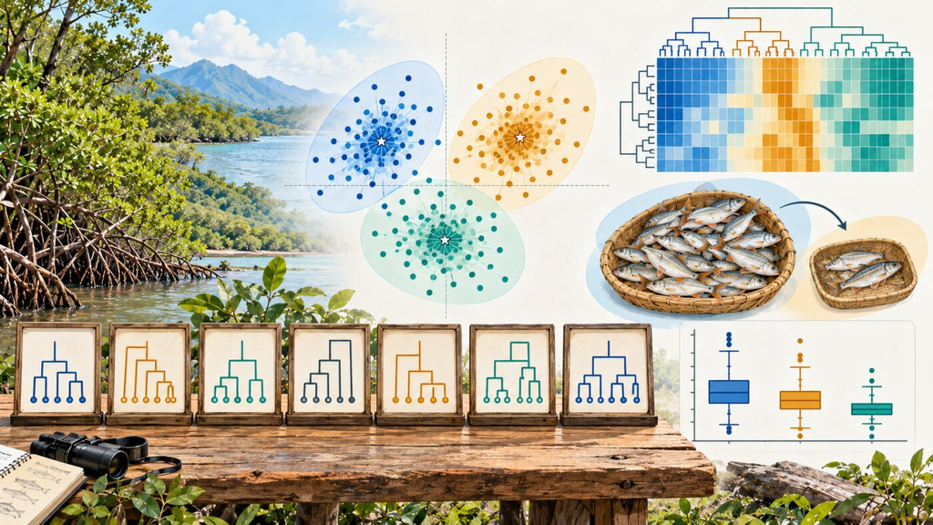

## Cómo usar este material

Este documento amplía el [Taller 10 · Clasificación y pruebas de hipótesis multivariadas](https://javier-2712.github.io/Manuales/8.Manual_diseno_msc/html/Taller10_Clasificacion_Pruebas.html). No es necesario recorrerlo completo: cada sección es independiente y responde a una situación que puede aparecer al preparar el estudio de caso o el propio proyecto de grado.

| Situación | Sección |
| --- | --- |
| Se quiere saber qué hace cada método de `hclust()` y por qué algunos dan árboles extraños | 1. Los siete métodos de unión |
| Se busca otra forma de decidir cuántos grupos tiene un dendrograma | 2. Niveles de fusión y silueta por objeto |
| Hay muchas observaciones o se quiere un agrupamiento no jerárquico | 3. k-means y PAM |
| Se quiere ver qué variables distinguen a cada grupo en una sola figura | 4. Mapa de calor de promedios por especie |
| Se quiere el biplot de la LDA con individuos, centroides y variables en una sola figura, o el discriminante canónico en un eje | 5. El biplot de la LDA en una sola figura y 5.1 Un eje |
| Se quiere validar la LDA con un conjunto de prueba | 6. Entrenamiento y prueba |
| Un artículo o un taller anterior usa ANOSIM o MRPP | 7. ANOSIM y MRPP |
| Se quiere saber qué variables difieren después de la MANOVA, o comparar Pillai, Wilks, Hotelling-Lawley y Roy | 8. ANOVA univariadas después de la MANOVA |
| La PERMANOVA tiene una variable continua y un factor que se solapan | 9. El orden de los términos en la PERMANOVA |
| El diseño tiene bloques y se quiere probar la dispersión con betadisper | 10. betadisper con bloques |
| Se usa `manyglm` y se quiere saber por qué Wald no, por qué la visita no va en `block =`, por qué no SIMPER y cómo entra el esfuerzo | 11. manyglm en detalle |
| Se quiere practicar antes del estudio de caso | 12. Ejercicios de práctica |

El guardado automático de figuras y tablas está en los materiales complementarios de los Talleres 6, 7 y 8; con los objetos de este documento funciona igual.

**Código**

```r
# Librerías requeridas
library(tidyverse)
library(readxl)
library(kableExtra)
library(vegan)
library(cluster)      # silueta y PAM
library(factoextra)   # dendrogramas y agrupamientos
library(ggrepel)      # rótulos sin superposición
library(ggforce)      # elipses por grupo
library(patchwork)    # paneles de figuras

# Formato común de números y tablas
source("formato.R")

# Paletas del módulo
col_esp  <- c("P. chola"      = "#2C6FB7",
              "P. conchonius" = "#E3A33B",
              "P. sophore"    = "#3E9C8F",
              "P. ticto"      = "#7B3294",
              "S. sarana"     = "#A6761D")
col_grp  <- c("1" = "#2C6FB7",
              "2" = "#E3A33B")
col_trib <- c(T1 = "#2C6FB7",
              T2 = "#E3A33B",
              T3 = "#3E9C8F")

# F y valor p de un permutest() de betadisper
F_bd <- function(pt) pt$tab$F[1]
p_bd <- function(pt) pt$tab$`Pr(>F)`[1]

# Índice de Rand ajustado: concordancia entre dos particiones (1 = idénticas; 0 = la del azar)
rand_aj <- function(a, b) {
  t  <- table(a, b)                     # tabla cruzada de las dos particiones
  n  <- sum(t)
  sc <- sum(choose(t, 2))               # pares juntos en las dos
  sa <- sum(choose(rowSums(t), 2))
  sb <- sum(choose(colSums(t), 2))
  e  <- sa * sb / choose(n, 2)          # lo esperado al azar
  (sc - e) / ((sa + sb) / 2 - e)
}
```

**Código**

```r
# Bahías de Santa Marta (Parte 1 del Taller 10)
fq <- read.csv2(ruta_datos("FQmarino.csv"),
                row.names = 1)
d_fq <- fq %>%
  scale() %>%                           # variables estandarizadas
  dist()                                # distancia euclídea
cla_up <- hclust(d_fq,
                 method = "average")    # UPGMA

# Peces: las 10 razones morfométricas, por nombre (Partes 2 y 3 del Taller 10)
peces <- read_xlsx(ruta_datos("datos.xlsx"),
                   .name_repair = "unique_quiet") %>%
  rename(Indice = 1) %>%
  mutate(Especie = factor(recode(Especie, "P. conchonious" = "P. conchonius")))   # corrige el nombre

vars_p  <- c("M.1", "M.2", "M.3", "M.4", "M.5",
             "M.6", "M.7", "M.13", "M.15", "M.18")
peces10 <- peces %>%
  select(all_of(vars_p))
d_peces <- dist(peces10)                # euclídea sobre las razones
```

## 1. Los siete métodos de unión

**Pregunta:** ¿Qué hace cada método de `hclust()` con las bahías, y por qué dos de ellos dan árboles que no se pueden leer?

El Taller 10 comparó UPGMA y Ward. `hclust()` ofrece ocho opciones (Ward en dos versiones), que difieren en cómo se mide la distancia entre un grupo recién formado y los demás:

| `method =` | Nombre | Distancia entre grupos |
| --- | --- | --- |
| `"single"` | Vecino más cercano | La del par más cercano |
| `"complete"` | Vecino más lejano | La del par más lejano |
| `"average"` | UPGMA | El promedio de todos los pares |
| `"mcquitty"` | WPGMA | El promedio de los dos grupos que se unieron, con igual peso |
| `"centroid"` | UPGMC | Entre los centroides |
| `"median"` | WPGMC | Entre los centroides, con igual peso para los dos grupos que se unieron |
| `"ward.D2"` | Ward | El aumento de la suma de cuadrados dentro de grupos |
| `"ward.D"` | Ward (versión antigua) | La misma idea, pero sin elevar las distancias al cuadrado |

En el taller de 2024, `"mcquitty"` aparecía como UPGMC, `"centroid"` como WPGMA y `"median"` como WPGMC; la tabla anterior usa los nombres correctos.

**Código**

```r
# Los ocho métodos de hclust()
metodos <- c(Simple   = "single",
             Completo = "complete",
             UPGMA    = "average",
             WPGMA    = "mcquitty",
             UPGMC    = "centroid",
             WPGMC    = "median",
             Ward     = "ward.D2",
             Ward.D   = "ward.D")
arboles <- map(metodos,
               ~ hclust(d_fq, method = .x))     # un árbol por método

# Cofenética, inversiones y grupo de Taganga con k = 2
tab_met <- tibble(Método     = names(metodos),
                  `method =` = unname(metodos),
                  Cofenética = map_dbl(arboles, ~ cor(d_fq, cophenetic(.x))),
                  Inversión  = map_lgl(arboles, ~ any(diff(.x$height) < 0)),   # una unión más baja que la anterior
                  `Grupos con k = 2` = map_chr(arboles, function(a) {
                    g <- cutree(a, k = 2)
                    paste(names(g)[g == g[1]], collapse = ", ")                # bahías que acompañan a Taganga
                  }))

tab_met %>%
  mutate(Inversión = if_else(Inversión, "Sí", "No")) %>%
  tabla(col.names = c("Método", "method =", "r cofenética", "Inversión",
                      "Grupo de Taganga con k = 2"))
```

| Método | method = | r cofenética | Inversión | Grupo de Taganga con k = 2 |
| --- | --- | --- | --- | --- |
| Simple | single | 0.736 | No | Taganga, PtaBetin, Monohuaca, Granate, P.Grande, Rodadero |
| Completo | complete | 0.811 | No | Taganga, PtaBetin, Monohuaca |
| UPGMA | average | 0.823 | No | Taganga, PtaBetin, Monohuaca |
| WPGMA | mcquitty | 0.821 | No | Taganga, PtaBetin, Monohuaca |
| UPGMC | centroid | 0.024 | Sí | Taganga, PtaBetin, Granate, P.Grande, Rodadero, Aeropuerto |
| WPGMC | median | 0.340 | Sí | Taganga, PtaBetin, Monohuaca, Granate, P.Grande, Rodadero |
| Ward | ward.D2 | 0.804 | No | Taganga, PtaBetin, Monohuaca |
| Ward.D | ward.D | 0.797 | No | Taganga, PtaBetin, Monohuaca |

**Código**

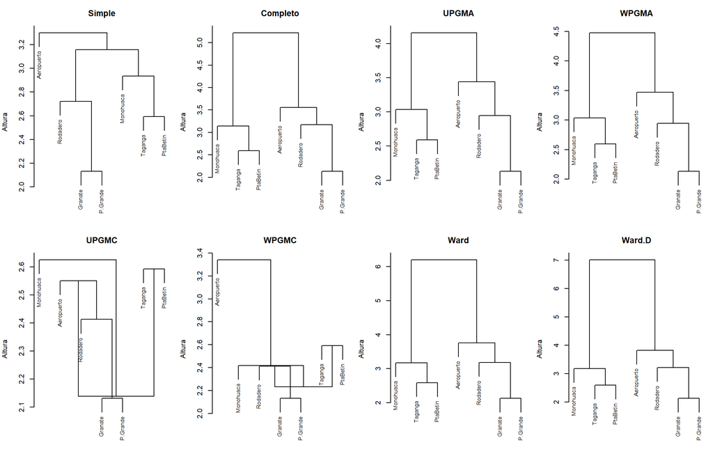

Figura 1: Dendrogramas de las siete bahías de Santa Marta con los ocho métodos de hclust() (distancia euclídea sobre variables estandarizadas). En UPGMC y WPGMC hay inversiones: un nodo queda más abajo que el anterior.

```r
# Los ocho árboles con vegan base
par(mfrow = c(2, 4),                    # dos filas de cuatro paneles
    mar = c(1, 4, 3, 1))
for (m in names(arboles)) {
  plot(arboles[[m]],
       main = m,
       xlab = "",
       sub = "",
       ylab = "Altura",
       cex = 0.8)
}
par(mfrow = c(1, 1))                    # vuelve a un panel
```

Tres lecturas:

- **UPGMA, WPGMA, completo y Ward** dan los mismos dos grupos del Taller 10 (Taganga, Punta Betín y Monohuaca frente al resto) y cofenéticas por encima de 0.80.
- **El vecino más cercano** produce **encadenamiento**: los objetos se van sumando uno a uno al mismo grupo, y con k = 2 el aeropuerto queda solo. Es útil para detectar valores atípicos, no para describir grupos.
- **UPGMC y WPGMC** tienen inversiones y cofenéticas de 0.02 y 0.34. Estos dos métodos suponen que la distancia es **euclídea al cuadrado** (la fórmula que actualiza los centroides solo es correcta en esa escala).

**Código**

```r
# UPGMC y WPGMC con la distancia euclídea al cuadrado, como suponen sus fórmulas
cuad <- map_dfr(c(UPGMC = "centroid",
                  WPGMC = "median"),
                function(m) {
                  a <- hclust(d_fq^2,                    # distancia al cuadrado
                              method = m)
                  tibble(Inversión  = any(diff(a$height) < 0),
                         Cofenética = cor(d_fq^2, cophenetic(a)),
                         Grupos     = paste(names(cutree(a, 2))[cutree(a, 2) == 1], collapse = ", "))
                },
                .id = "Método")

cuad %>%
  mutate(Inversión = if_else(Inversión, "Sí", "No")) %>%
  tabla(col.names = c("Método", "Inversión", "r cofenética (d²)", "Grupo de Taganga con k = 2"))
```

| Método | Inversión | r cofenética (d²) | Grupo de Taganga con k = 2 |
| --- | --- | --- | --- |
| UPGMC | No | 0.763 | Taganga, PtaBetin, Monohuaca |
| WPGMC | No | 0.774 | Taganga, PtaBetin, Monohuaca |

Con la distancia al cuadrado desaparecen las inversiones y los dos métodos recuperan los mismos grupos. No es un error de R, sino un mal uso del método.

**Nota`"ward.D"` frente a `"ward.D2"`**

`"ward.D"` aplica la fórmula de Ward a las distancias sin elevarlas al cuadrado; solo es correcto si se le entrega una matriz de distancias ya al cuadrado. `"ward.D2"` hace el cuadrado internamente y es la opción que se usa en el módulo. Aquí dan los mismos grupos, pero las alturas del árbol cambian (7.02 frente a 6.20 en el nodo superior).

**Para discutir:** si un artículo reporta un dendrograma con el método de centroide y distancia de Bray-Curtis, ¿qué se revisaría en la figura?

## 2. Niveles de fusión y silueta por objeto

**Pregunta:** ¿Qué otra pista, además de la silueta media, ayuda a decidir cuántos grupos tiene el dendrograma de las bahías?

### 2.1 Niveles de fusión

Los **niveles de fusión** son las alturas a las que se unen los grupos. Un salto grande entre dos niveles sucesivos indica que se están uniendo grupos muy distintos: es un buen lugar para cortar.

**Código**

```r
# Alturas de unión del UPGMA y número de grupos antes y después de cada una
fusion <- tibble(Altura    = cla_up$height,
                 k_antes   = nrow(fq):2,
                 k_despues = (nrow(fq) - 1):1) %>%
  mutate(Salto = Altura - lag(Altura))          # la primera unión no tiene salto

fusion %>%
  tabla(col.names = c("Altura de unión", "Grupos antes", "Grupos después", "Salto desde la anterior"))
```

| Altura de unión | Grupos antes | Grupos después | Salto desde la anterior |
| --- | --- | --- | --- |
| 2.132 | 7 | 6 | NA |
| 2.593 | 6 | 5 | 0.461 |
| 2.946 | 5 | 4 | 0.353 |
| 3.037 | 4 | 3 | 0.092 |
| 3.442 | 3 | 2 | 0.404 |
| 4.157 | 2 | 1 | 0.716 |

**Código**

```r
salto_max <- fusion %>%
  slice_max(Salto,
            na_rm = TRUE)                       # el mayor salto
```

**Código**

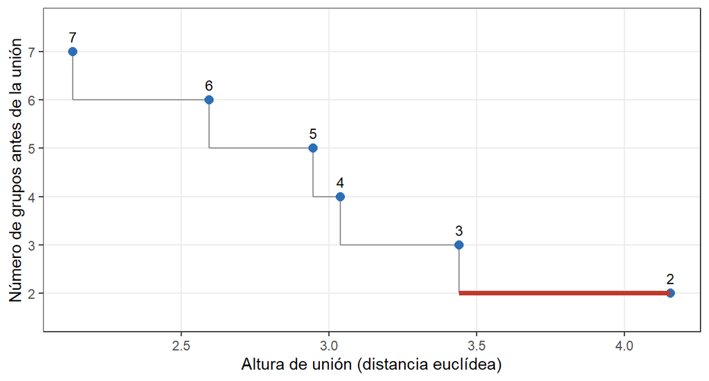

Figura 2: Niveles de fusión del dendrograma UPGMA de las bahías. El salto más grande (barra resaltada) está en la última unión: cortar justo antes deja dos grupos.

```r
# Escalera de niveles de fusión
ggplot(fusion,
       aes(x = Altura,
           y = k_antes)) +
  geom_step(direction = "vh",
            colour = "grey55") +
  geom_point(colour = "#2C6FB7",
             size = 2.5) +
  geom_segment(data = salto_max,
               aes(x = Altura - Salto,
                   xend = Altura,
                   y = k_antes,
                   yend = k_antes),             # marca el mayor salto
               colour = "#C0392B",
               linewidth = 1.5) +
  geom_text(aes(label = k_antes),
            vjust = -0.9,
            size = 3.3) +
  scale_y_continuous(breaks = 2:7,
                     limits = c(1.5, 7.6)) +
  labs(x = "Altura de unión (distancia euclídea)",
       y = "Número de grupos antes de la unión") +
  theme_bw() +
  theme(panel.grid.minor = element_blank())
```

El mayor salto (0.72) ocurre al pasar de 2 grupos a 1: cortar antes de esa unión deja **dos grupos**, lo mismo que sugirió la silueta en el Taller 10.

### 2.2 Silueta de cada bahía

**Código**

```r
# Silueta de cada bahía con k = 2
grp_fq <- cutree(cla_up,
                 k = 2)
sil_fq <- silhouette(grp_fq,
                     d_fq)                      # silueta, grupo y grupo vecino

sil_bah <- tibble(Bahia   = rownames(fq),
                  Grupo   = factor(sil_fq[, "cluster"]),
                  Vecino  = factor(sil_fq[, "neighbor"]),
                  Silueta = sil_fq[, "sil_width"]) %>%
  arrange(Grupo, desc(Silueta)) %>%
  mutate(Bahia = fct_inorder(Bahia))            # orden de las barras
```

**Código**

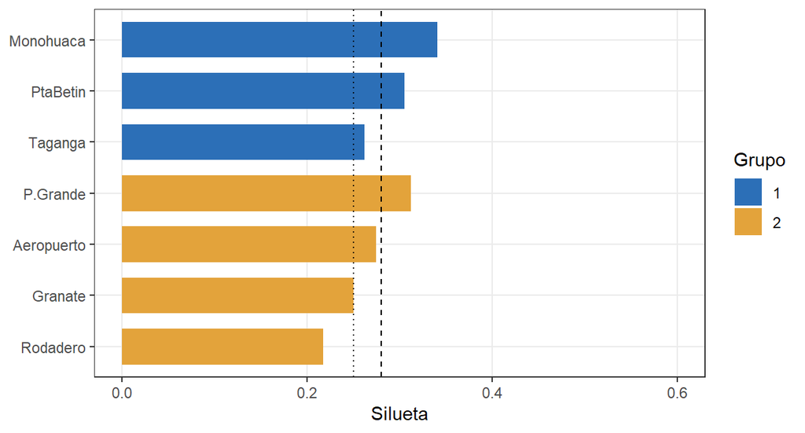

Figura 3: Silueta de cada bahía en el corte en dos grupos del UPGMA. La línea discontinua es la silueta media; la punteada marca 0.25, el límite de una estructura débil.

```r
# Barras de silueta por bahía
ggplot(sil_bah,
       aes(x = Silueta,
           y = fct_rev(Bahia),
           fill = Grupo)) +
  geom_col(width = 0.7) +
  geom_vline(xintercept = mean(sil_bah$Silueta),   # silueta media
             linetype = 2) +
  geom_vline(xintercept = 0.25,                    # límite de estructura débil
             linetype = 3) +
  scale_fill_manual(values = col_grp) +
  scale_x_continuous(limits = c(0, 0.6)) +
  labs(x = "Silueta",
       y = NULL,
       fill = "Grupo") +
  theme_bw() +
  theme(panel.grid.minor = element_blank())
```

Ninguna bahía tiene silueta negativa, pero 2 quedan por debajo de 0.25: Granate y Rodadero. Son las que más se parecen al otro grupo, y las primeras que cambiarían de grupo con otra distancia u otro método. `fviz_silhouette(sil_fq)` de `factoextra` dibuja la misma figura en una línea.

**Para discutir:** si la silueta media sugiriera k = 2 y los niveles de fusión k = 3, ¿qué otro criterio, fuera de la estadística, ayudaría a decidir?

## 3. k-means y PAM: agrupamientos no jerárquicos

**Pregunta:** Sin conocer las especies, ¿encuentra un agrupamiento no jerárquico los cinco grupos de peces?

El **k-means** no construye un árbol: fija de antemano k grupos, ubica k centroides y reasigna cada objeto al centroide más cercano hasta que nada cambia. Es rápido con miles de observaciones, pero su resultado depende del punto de partida (por eso se usa `nstart` alto) y solo funciona con distancia euclídea sobre una matriz de datos.

### 3.1 Las bahías

**Código**

```r
# k-means de las bahías con k = 2
set.seed(2026)
km_fq <- kmeans(scale(fq),
                centers = 2,
                nstart = 50)                    # 50 puntos de partida

table(UPGMA  = grp_fq,
      kmeans = km_fq$cluster)
```

```
     kmeans
UPGMA 1 2
    1 0 3
    2 4 0
```

Con siete bahías, el k-means encuentra exactamente los mismos dos grupos del UPGMA (los números de los grupos son arbitrarios). Con pocos objetos, el agrupamiento jerárquico es preferible porque muestra toda la estructura; el k-means rinde cuando hay cientos de observaciones.

### 3.2 Los peces: ¿cuántos grupos hay?

**Código**

```r
# UPGMA de los peces
cla_p <- hclust(d_peces,
                method = "average")

# Silueta media del k-means y del UPGMA para k = 2 a 8
sil_peces <- map_dfr(2:8, function(k) {
  set.seed(2026)
  km <- kmeans(peces10,
               centers = k,
               nstart = 50)
  tibble(k      = k,
         kmeans = mean(silhouette(km$cluster, d_peces)[, "sil_width"]),
         UPGMA  = mean(silhouette(cutree(cla_p, k), d_peces)[, "sil_width"]))
})

sil_peces %>%
  tabla(col.names = c("k", "Silueta media (k-means)", "Silueta media (UPGMA)"))
```

| k | Silueta media (k-means) | Silueta media (UPGMA) |
| --- | --- | --- |
| 2 | 0.491 | 0.491 |
| 3 | 0.396 | 0.401 |
| 4 | 0.387 | 0.382 |
| 5 | 0.408 | 0.333 |
| 6 | 0.275 | 0.262 |
| 7 | 0.257 | 0.323 |
| 8 | 0.246 | 0.317 |

Los dos métodos coinciden: la mejor partición tiene **dos grupos** (silueta = 0.49). Al revisarlos, uno es *S. sarana* y el otro reúne a las cuatro especies de *Puntius*. Los datos, sin ayuda, «ven» el género, no la especie.

### 3.3 Forzar cinco grupos

**Código**

```r
# k-means con k = 5
set.seed(2026)
km_p <- kmeans(peces10,
               centers = 5,
               nstart = 50)

# Tres particiones en 5 grupos
part5 <- list(kmeans = km_p$cluster,
              UPGMA  = cutree(cla_p, 5),
              Ward   = cutree(hclust(d_peces, method = "ward.D2"), 5))

# ¿Cuánto se parecen a las especies?
map_dfr(part5,
        ~ tibble(`Rand ajustado` = rand_aj(peces$Especie, .x)),
        .id = "Método") %>%
  tabla()
```

| Método | Rand ajustado |
| --- | --- |
| kmeans | 0.750 |
| UPGMA | 0.526 |
| Ward | 0.716 |

**Código**

```r
table(Especie      = peces$Especie,
      Grupo_kmeans = km_p$cluster)
```

```
               Grupo_kmeans
Especie          1  2  3  4  5
  P. chola       0 12  0  0  0
  P. conchonius  0  2  0  6  0
  P. sophore     0  6  0  0  0
  P. ticto       9  0 11  0  0
  S. sarana      0  0  0  0 24
```

**Código**

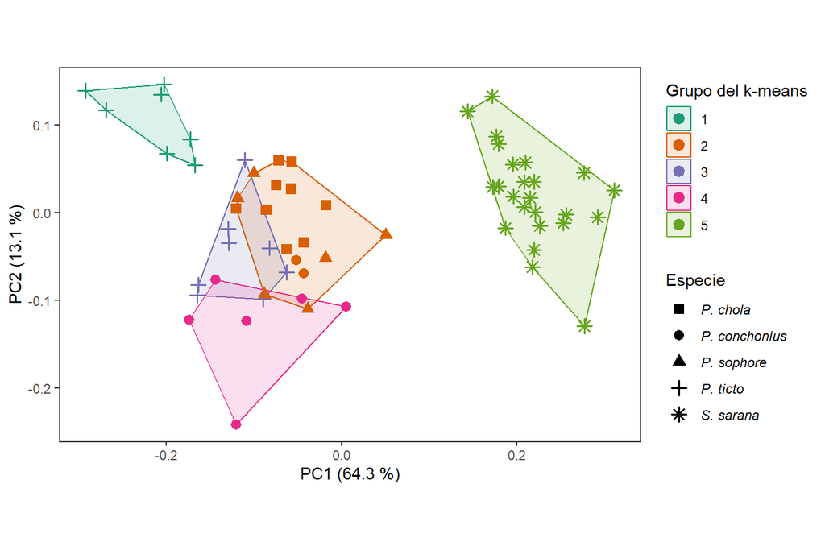

Figura 4: Cinco grupos del k-means de los peces sobre los dos primeros componentes de un PCA de las 10 razones (sin estandarizar). Color y contorno: grupo del k-means; forma: especie real.

```r
# PCA de covarianza de las razones
pca_p  <- prcomp(peces10)
pct_pc <- 100 * pca_p$sdev^2 / sum(pca_p$sdev^2)   # % de varianza por eje

# Coordenadas de los peces en los dos primeros componentes
coord_km <- pca_p$x[, 1:2] %>%
  as_tibble() %>%
  mutate(Especie = peces$Especie,
         Grupo   = factor(km_p$cluster))

# Contorno de cada grupo del k-means (envolvente convexa)
contorno_km <- coord_km %>%
  group_by(Grupo) %>%
  slice(chull(PC1, PC2)) %>%                        # puntos del borde
  ungroup()

# Grupos del k-means (color y contorno) y especie real (forma)
ggplot(coord_km,
       aes(x = PC1,
           y = PC2)) +
  geom_polygon(data = contorno_km,
               aes(fill = Grupo,
                   colour = Grupo),
               alpha = 0.15) +
  geom_point(aes(colour = Grupo,
                 shape = Especie),
             size = 2.6,
             stroke = 0.9) +
  scale_shape_manual(values = c(15, 16, 17, 3, 8)) +
  scale_colour_brewer(palette = "Dark2") +
  scale_fill_brewer(palette = "Dark2") +
  guides(shape = guide_legend(label.theme = element_text(face = "italic", size = 9))) +   # especies en cursiva
  coord_equal() +
  labs(x = paste0("PC1 (", f1(pct_pc[1]), " %)"),
       y = paste0("PC2 (", f1(pct_pc[2]), " %)"),
       colour = "Grupo del k-means",
       fill = "Grupo del k-means") +
  theme_bw() +
  theme(panel.grid = element_blank())
```

El **índice de Rand ajustado** compara dos particiones: 1 si son idénticas y cerca de 0 si coinciden como al azar. El k-means (0.75) y Ward (0.72) recuperan mejor las especies que UPGMA (0.53), pero ninguno las reproduce: *P. chola* y *P. sophore* caen juntas, y *P. ticto* se parte en dos. Es la misma confusión que la LDA del Taller 10, ahora sin conocer las respuestas.

**ImportanteAgrupar no es clasificar**

El CLA y el k-means proponen grupos a partir de los datos; la LDA aprende a separar grupos que ya se conocen. Que el k-means no recupere las especies no dice que la morfometría no las distinga (la LDA lo hace con un 90 % de acierto en validación cruzada), sino que la mayor diferencia en los datos (el género) domina sobre las diferencias entre especies cercanas.

**TipPAM: k-medoides con cualquier distancia**

Con abundancias y Bray-Curtis, el k-means no sirve, porque necesita centroides euclidianos. `pam()` de `cluster` usa como centro de cada grupo una observación real (el **medoide**) y acepta cualquier matriz de distancias:

**Código**

```r
# PAM con la distancia de los peces y k = 5
pam_p <- pam(d_peces,                   # acepta cualquier matriz de distancias
             k = 5)

c(Rand_ajustado = rand_aj(peces$Especie, pam_p$clustering),
  silueta_media = pam_p$silinfo$avg.width)
```

```
Rand_ajustado silueta_media
    0.6617558     0.3271577
```

Con la misma matriz de los peces, PAM da un índice de Rand ajustado de 0.66. Para el plancton o las microalgas se le entregaría la Bray-Curtis del Taller 8.

**Para discutir:** en un estudio de praderas de pastos marinos con 120 estaciones y su fauna asociada, ¿qué método de agrupamiento se usaría y con qué distancia?

## 4. Mapa de calor de promedios por especie

**Pregunta:** ¿Qué medidas distinguen a cada especie, vistas todas a la vez?

El mapa de calor opcional del Taller 10 mostraba las bahías. Con 70 peces, un mapa por individuo es ilegible; se resume primero cada especie por su promedio y se estandariza cada medida para que los colores sean comparables.

**Código**

```r
# Promedio de cada medida por especie
prom_esp <- peces %>%
  group_by(Especie) %>%
  summarise(across(all_of(vars_p), mean),
            .groups = "drop")

# Promedios estandarizados entre especies (z por medida)
prom_z <- prom_esp %>%
  column_to_rownames("Especie") %>%
  scale()

# Orden de especies y medidas según su propio agrupamiento (UPGMA)
orden_esp <- rownames(prom_z)[hclust(dist(prom_z), "average")$order]
orden_med <- colnames(prom_z)[hclust(dist(t(prom_z)), "average")$order]

# Tabla larga con z y promedio, lista para geom_tile()
calor <- as_tibble(prom_z,
                   rownames = "Especie") %>%
  pivot_longer(-Especie,
               names_to = "Medida",
               values_to = "z") %>%
  left_join(prom_esp %>%
              pivot_longer(-Especie,
                           names_to = "Medida",
                           values_to = "Promedio"),
            by = c("Especie", "Medida")) %>%
  mutate(Especie = factor(Especie, levels = orden_esp),
         Medida  = factor(Medida, levels = orden_med))
```

**Código**

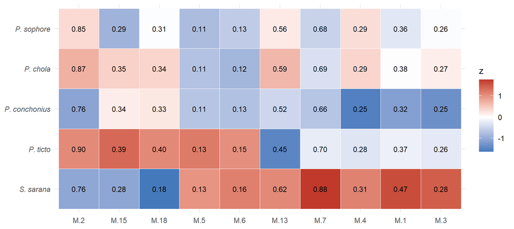

Figura 5: Promedio de cada razón morfométrica por especie. El color es el valor estandarizado entre especies (rojo: por encima del promedio; azul: por debajo); el número es el promedio de la razón. Especies y medidas se ordenan por su propio agrupamiento UPGMA.

```r
# Mapa de calor con ggplot2
ggplot(calor,
       aes(x = Medida,
           y = Especie,
           fill = z)) +
  geom_tile(colour = "white") +
  geom_text(aes(label = f2(Promedio)),          # promedio dentro de cada celda
            size = 3) +
  scale_fill_gradient2(low = "#2C6FB7",
                       mid = "white",
                       high = "#C0392B") +
  labs(x = NULL,
       y = NULL,
       fill = "z") +
  theme_minimal() +
  theme(axis.text.y = element_text(face = "italic"))
```

*S. sarana* ocupa su propia fila de contrastes: valores altos en las medidas que se agrupan con M.1 y M.7 y bajos en M.15 y M.18, las mismas que apuntaban hacia ella en el biplot canónico del Taller 10. Entre las *Puntius*, *P. chola* y *P. sophore* tienen filas casi iguales: por eso la LDA las confunde. El mapa de calor no prueba nada, pero ayuda a escribir la discusión: dice **en qué** difieren los grupos que la PERMANOVA declaró distintos.

**Para discutir:** ¿qué se perdería si el mapa se hiciera con los promedios sin estandarizar?

## 5. El biplot de la LDA en una sola figura

**Pregunta:** ¿Cómo se reúnen en una figura los peces, el centro de cada especie y las medidas que las separan, y dónde quedan los peces mal clasificados?

El biplot canónico del Taller 10 mostraba los peces con elipses y las medidas como flechas. Aquí se arma la versión completa por capas, como el triplot de la RDA del Taller 9 y el biplot del NMDS del Taller 8: primero se extraen las coordenadas de cada elemento en una tabla y luego se superponen en `ggplot2`.

**Código**

```r
# LDA con resustitución y con validación cruzada (como en la Parte 2 del Taller 10)
lda_p <- MASS::lda(peces10,
                   grouping = peces$Especie)
cv_p  <- MASS::lda(peces10,
                   grouping = peces$Especie,
                   CV = TRUE)                   # dejando uno fuera

# Porcentaje de la separación entre grupos de cada función
pct_ld <- 100 * lda_p$svd^2 / sum(lda_p$svd^2)
names(pct_ld) <- colnames(lda_p$scaling)
```

### Coordenadas de los peces

**Código**

```r
# Coordenadas de cada pez en LD1 y LD2, con la especie asignada en la validación cruzada
coord_pez <- predict(lda_p)$x[, 1:2] %>%
  as_tibble() %>%
  mutate(Indice    = peces$Indice,
         Especie   = peces$Especie,
         Asignada  = cv_p$class,
         Prob      = apply(cv_p$posterior, 1, max),                       # probabilidad de la asignada
         Resultado = if_else(Asignada == Especie, "Correcta", "Errónea")) %>%
  relocate(Indice, Especie)

coord_pez %>%
  head() %>%
  tabla()
```

| Indice | Especie | LD1 | LD2 | Asignada | Prob | Resultado |
| --- | --- | --- | --- | --- | --- | --- |
| 1 | P. chola | -1.189 | 3.635 | P. sophore | 0.657 | Errónea |
| 2 | P. chola | -0.691 | 1.717 | P. chola | 0.687 | Correcta |
| 3 | P. chola | -2.640 | 3.036 | P. chola | 0.999 | Correcta |
| 4 | P. chola | -2.090 | 1.179 | P. chola | 0.747 | Correcta |
| 5 | P. chola | -1.445 | 2.467 | P. chola | 0.902 | Correcta |
| 6 | P. chola | -1.314 | 2.953 | P. chola | 0.842 | Correcta |

### Coordenadas de los centroides

El centroide de cada especie es el promedio de las coordenadas de sus peces. Es el punto al que la LDA compara cada pez para asignarlo.

**Código**

```r
# Centroide de cada especie en el plano LD1–LD2
coord_cen <- coord_pez %>%
  group_by(Especie) %>%
  summarise(n   = n(),
            LD1 = mean(LD1),                    # promedio de sus peces
            LD2 = mean(LD2),
            .groups = "drop")

coord_cen %>%
  tabla()
```

| Especie | n | LD1 | LD2 |
| --- | --- | --- | --- |
| P. chola | 12 | -1.204 | 2.768 |
| P. conchonius | 8 | -3.755 | 0.281 |
| P. sophore | 6 | -1.314 | 3.017 |
| P. ticto | 20 | -4.858 | -1.831 |
| S. sarana | 24 | 6.231 | -0.706 |

### Coordenadas de las medidas

Las flechas son los **coeficientes de estructura**: la correlación de cada medida con LD1 y LD2. Van de −1 a 1, mientras que los peces se extienden varias unidades, así que se multiplican por un factor común que no cambia su dirección ni sus longitudes relativas.

**Código**

```r
# Correlación de cada medida con las dos funciones discriminantes
coord_med <- cor(peces10, predict(lda_p)$x[, 1:2]) %>%
  as_tibble(rownames = "Medida") %>%
  mutate(Largo = sqrt(LD1^2 + LD2^2))           # qué tan bien la representa el plano

# Factor que lleva la flecha más larga al 80 % del rango de los peces
mult_med <- 0.8 * max(abs(c(coord_pez$LD1, coord_pez$LD2))) /
  max(abs(c(coord_med$LD1, coord_med$LD2)))

coord_med %>%
  mutate(LD1_figura = LD1 * mult_med,
         LD2_figura = LD2 * mult_med) %>%
  arrange(desc(Largo)) %>%
  tabla()
```

| Medida | LD1 | LD2 | Largo | LD1_figura | LD2_figura |
| --- | --- | --- | --- | --- | --- |
| M.7 | 0.880 | -0.359 | 0.950 | 6.474 | -2.645 |
| M.1 | 0.890 | -0.259 | 0.927 | 6.549 | -1.910 |
| M.13 | 0.750 | 0.423 | 0.861 | 5.519 | 3.110 |
| M.18 | -0.792 | 0.005 | 0.792 | -5.826 | 0.037 |
| M.15 | -0.698 | -0.237 | 0.737 | -5.136 | -1.743 |
| M.6 | 0.269 | -0.681 | 0.732 | 1.982 | -5.009 |
| M.5 | 0.148 | -0.646 | 0.663 | 1.088 | -4.757 |
| M.4 | 0.650 | 0.049 | 0.652 | 4.783 | 0.362 |
| M.2 | -0.640 | 0.047 | 0.641 | -4.708 | 0.348 |
| M.3 | 0.588 | -0.087 | 0.594 | 4.325 | -0.640 |

### Figura

**Código**

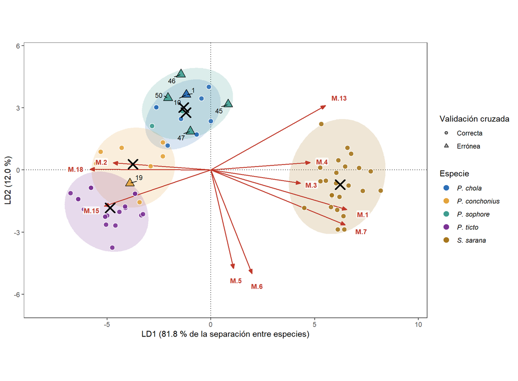

Figura 6: Biplot de la LDA de las cinco especies de peces. Círculos: peces bien clasificados con validación cruzada; triángulos con borde negro: peces mal clasificados (número: índice del pez). Una elipse envuelve los peces de cada especie y la cruz negra marca su centroide. Flechas rojas: correlaciones de estructura de cada medida, multiplicadas por un factor común para caber en la figura.

```r
# Biplot por capas: elipses, medidas, peces y centroides
ggplot() +
  geom_hline(yintercept = 0,
             linetype = 3) +
  geom_vline(xintercept = 0,
             linetype = 3) +
  geom_mark_ellipse(data = coord_pez,                  # capa 1: elipse por especie
                    aes(x = LD1,
                        y = LD2,
                        fill = Especie,
                        group = Especie),
                    colour = NA,
                    alpha = 0.18,
                    expand = unit(2, "mm"),
                    show.legend = FALSE) +
  geom_segment(data = coord_med,                       # capa 2: flechas de las medidas
               aes(x = 0,
                   y = 0,
                   xend = LD1 * mult_med,
                   yend = LD2 * mult_med),
               arrow = arrow(angle = 22.5,
                             length = unit(0.22, "cm"),
                             type = "closed"),
               linewidth = 0.6,
               colour = "#C0392B") +
  geom_point(data = coord_pez,                         # capa 3: peces
             aes(x = LD1,
                 y = LD2,
                 fill = Especie,
                 shape = Resultado,                    # círculo o triángulo
                 colour = Resultado,
                 size = Resultado),
             stroke = 0.7,
             alpha = 0.9) +
  geom_text_repel(data = filter(coord_pez, Resultado == "Errónea"),   # índice de los mal clasificados
                  aes(x = LD1,
                      y = LD2,
                      label = Indice),
                  size = 3,
                  colour = "black",
                  min.segment.length = 0,
                  box.padding = 0.4,
                  seed = 2026) +
  geom_label(data = coord_med,                         # capa 4: nombres de las medidas
             aes(x = LD1 * mult_med * 1.12,
                 y = LD2 * mult_med * 1.12,
                 label = Medida),
             colour = "#C0392B",
             fill = alpha("white", 0.75),
             fontface = "bold",
             size = 3.2,
             label.size = 0,
             label.padding = unit(0.1, "lines")) +
  geom_point(data = coord_cen,                         # capa 5: centroides
             aes(x = LD1,
                 y = LD2),
             shape = 4,
             size = 4.5,
             stroke = 1.8,
             colour = "black") +
  scale_fill_manual(values = col_esp) +
  scale_shape_manual(values = c(Correcta = 21,
                                Errónea = 24)) +
  scale_colour_manual(values = c(Correcta = "white",
                                 Errónea = "black")) +
  scale_size_manual(values = c(Correcta = 2.8,
                               Errónea = 3.8)) +
  scale_x_continuous(expand = expansion(mult = 0.15)) +   # espacio para elipses y rótulos
  scale_y_continuous(expand = expansion(mult = 0.15)) +
  coord_equal() +
  guides(fill = guide_legend(override.aes = list(shape = 21,
                                                 size = 3.5,
                                                 colour = "white",
                                                 alpha = 1),
                             label.theme = element_text(face = "italic",
                                                        size = 9)),   # especies en cursiva
         shape = guide_legend(override.aes = list(fill = "grey60")),
         colour = "none",
         size = "none") +
  labs(x = paste0("LD1 (", f1(pct_ld[1]), " % de la separación entre especies)"),
       y = paste0("LD2 (", f1(pct_ld[2]), " %)"),
       fill = "Especie",
       shape = "Validación cruzada") +
  theme_bw() +
  theme(panel.grid = element_blank())
```

**Código**

```r
# Peces mal clasificados con validación cruzada
mal <- coord_pez %>%
  filter(Resultado == "Errónea") %>%
  select(Indice, Especie, Asignada, Prob, LD1, LD2)

mal %>%
  tabla(col.names = c("Índice", "Especie real", "Asignada (validación cruzada)",
                      "Probabilidad de la asignada", "LD1", "LD2"))
```

| Índice | Especie real | Asignada (validación cruzada) | Probabilidad de la asignada | LD1 | LD2 |
| --- | --- | --- | --- | --- | --- |
| 1 | P. chola | P. sophore | 0.657 | -1.189 | 3.635 |
| 10 | P. chola | P. sophore | 0.657 | -1.189 | 3.635 |
| 19 | P. conchonius | P. ticto | 0.651 | -3.905 | -0.642 |
| 45 | P. sophore | P. chola | 0.657 | 0.829 | 3.169 |
| 46 | P. sophore | P. chola | 0.998 | -1.445 | 4.615 |
| 47 | P. sophore | P. chola | 0.987 | -0.990 | 1.866 |
| 50 | P. sophore | P. chola | 0.999 | -2.066 | 3.481 |

**AdvertenciaDos peces en el mismo punto**

Los peces 1 y 10 tienen las mismas coordenadas porque sus 10 medidas son idénticas. En la base hay más casos así:

**Código**

```r
# Peces con las 10 medidas repetidas
rep_10 <- peces$Indice[duplicated(peces10) |
                         duplicated(peces10, fromLast = TRUE)]   # el primero y el repetido

# Peces idénticos en todas las columnas
rep_todo <- peces$Indice[duplicated(select(peces, -Indice)) |
                           duplicated(select(peces, -Indice), fromLast = TRUE)]

list(diez_medidas_iguales       = rep_10,
     todas_las_columnas_iguales = rep_todo)
```

```
$diez_medidas_iguales
 [1]  1  2  3 10 11 12 51 52 57 58 61 64 65 67 68

$todas_las_columnas_iguales
[1]  3 12
```

Con razones redondeadas a dos decimales, que dos peces coincidan en una medida es esperable, pero que coincidan en las 10 sugiere filas copiadas al digitar la base (los peces 3 y 12 son idénticos en las 31 columnas). Antes de un análisis definitivo se revisan los duplicados con `duplicated()`: un pez repetido cuenta dos veces en la LDA y en la PERMANOVA.

**NotaPor qué los centroides y no las elipses**

La LDA asigna cada pez a la especie con mayor probabilidad posterior, que depende de su distancia (de Mahalanobis) al centroide de cada especie y de las probabilidades a priori. Las elipses solo envuelven a los peces de cada especie; dos elipses pueden solaparse mucho y aun así los centroides separar bien a la mayoría. Por eso la figura marca cada centroide con una cruz negra.

**TipCómo reportar el resultado**

> El análisis discriminante lineal de las 10 razones morfométricas clasificó correctamente el 90,0 % de los peces con validación cruzada dejando uno fuera. La primera función discriminante resumió el 81,8 % de la separación entre especies y separó a *S. sarana* de las especies de *Puntius* (asociada con M.1 y M.7); la segunda (12,0 %) separó a *P. ticto*. Los 7 errores de clasificación ocurrieron entre especies cercanas, principalmente *P. chola* y *P. sophore*.

**Para discutir:** si los peces mal clasificados fueran juveniles, ¿qué diría eso del diseño del muestreo? ¿Cómo se incluiría la talla en el análisis?

### 5.1 El discriminante canónico en un eje

El biplot resume dos funciones a la vez. Cuando LD1 concentra casi toda la separación (81.8 %), basta un eje: a la izquierda, la puntuación de cada pez en LD1 por especie; a la derecha, la correlación de cada medida con LD1 (la **estructura**). El Taller 10 (Parte 2, Paso 3.2) la hace con `plot()` de `candisc::candisc()`; aquí se arma la misma figura en `ggplot2` con las tablas de esta sección, para cambiar colores, rótulos u orden de las medidas.

**Código**

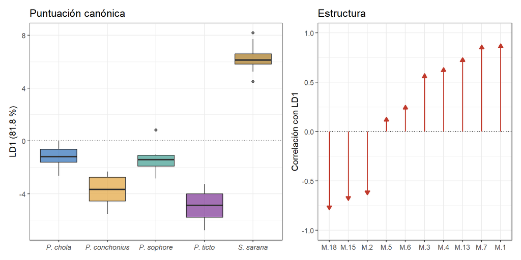

Figura 7: Discriminante canónico en un eje. Izquierda: puntuación de cada pez en LD1 por especie. Derecha: correlación de estructura de cada medida con LD1; una flecha hacia arriba indica que la medida crece hacia las especies con puntuación alta.

```r
# Panel 1 · puntuación canónica de los peces en LD1
p_punt <- ggplot(coord_pez,
                 aes(x = Especie,
                     y = LD1,
                     fill = Especie)) +
  geom_hline(yintercept = 0,
             linetype = 3) +
  geom_boxplot(alpha = 0.7,
               show.legend = FALSE) +
  scale_fill_manual(values = col_esp) +
  labs(title = "Puntuación canónica",
       x = NULL,
       y = paste0("LD1 (", f1(pct_ld[1]), " %)")) +
  theme_bw() +
  theme(axis.text.x = element_text(face = "italic"))

# Panel 2 · estructura: correlación de cada medida con LD1
p_estr <- coord_med %>%
  mutate(Medida = fct_reorder(Medida, LD1)) %>%   # de la más negativa a la más positiva
  ggplot(aes(x = Medida,
             y = 0,
             xend = Medida,
             yend = LD1)) +
  geom_hline(yintercept = 0,
             linetype = 3) +
  geom_segment(arrow = arrow(length = unit(0.2, "cm"),
                             type = "closed"),
               colour = "#C0392B",
               linewidth = 0.7) +
  scale_y_continuous(limits = c(-1, 1)) +
  labs(title = "Estructura",
       x = NULL,
       y = "Correlación con LD1") +
  theme_bw()

p_punt + p_estr +
  plot_layout(widths = c(1.3, 1))
```

**Código**

```r
# Media de LD1 por especie, de mayor a menor
coord_cen %>%
  arrange(desc(LD1)) %>%
  select(Especie, n, LD1) %>%
  tabla(digits = 2)
```

| Especie | n | LD1 |
| --- | --- | --- |
| S. sarana | 24 | 6.23 |
| P. chola | 12 | -1.20 |
| P. sophore | 6 | -1.31 |
| P. conchonius | 8 | -3.75 |
| P. ticto | 20 | -4.86 |

Las cajas se leen como una ANOVA de un eje: *S. sarana* (media 6.23) queda sola en un extremo, y las cuatro *Puntius* se reparten al otro lado, con *P. chola* y *P. sophore* solapadas, la misma confusión de la validación cruzada. Las flechas dicen por qué: las medidas con correlación positiva (M.1 y M.7, cercanas a 0.89) son mayores en las especies de puntuación alta, y las de correlación negativa (M.18, -0.79) en las de puntuación baja. El eje no separa a *P. chola* de *P. sophore*; para eso hace falta el segundo eje del biplot, y aun así se solapan.

**NotaDiferencias con el taller de pregrado**

El Taller 7.1 del curso de pregrado ajusta la LDA con el 80 % de los peces (entrenamiento) y por eso su eje canónico resume el 77.4 %; aquí se usan los 70 peces, como en el Taller 10 y en la presentación 10 (81.8 %). El signo del eje es arbitrario: `candisc` y `MASS::lda()` pueden dar el eje invertido, con las mismas conclusiones.

## 6. Entrenamiento y prueba

**Pregunta:** ¿Qué pasa si la LDA se valida con un conjunto de prueba separado, como hacía el taller de 2024?

El taller de 2024 separaba los peces en un 80 % de entrenamiento y un 20 % de prueba con el paquete `caret`. La partición se puede hacer sin paquetes adicionales, estratificada por especie para que todas estén en los dos conjuntos:

**Código**

```r
# Filas de cada especie
filas_esp <- split(seq_len(nrow(peces)),
                   peces$Especie)

# Una partición 80/20 estratificada por especie
set.seed(2026)
entrena <- unlist(map(filas_esp,
                      ~ sample(.x, round(0.8 * length(.x)))))   # 80 % de cada especie

lda_ent   <- MASS::lda(peces10[entrena, ],
                       grouping = peces$Especie[entrena])        # se ajusta con el entrenamiento
pred_pru  <- predict(lda_ent,
                     peces10[-entrena, ])$class                  # se prueba con el resto
acierto_1 <- mean(pred_pru == peces$Especie[-entrena])

c(entrenamiento = length(entrena),
  prueba        = nrow(peces) - length(entrena))
```

```
entrenamiento        prueba
           56            14
```

**Código**

```r
table(Real     = peces$Especie[-entrena],
      Asignada = pred_pru)
```

```
               Asignada
Real            P. chola P. conchonius P. sophore P. ticto S. sarana
  P. chola             1             0          1        0         0
  P. conchonius        0             2          0        0         0
  P. sophore           1             0          0        0         0
  P. ticto             0             0          0        4         0
  S. sarana            0             0          0        0         5
```

Con esta partición, la LDA acierta el 85.7 % de los 14 peces de prueba. Pero el conjunto de prueba tiene solo 1 *P. sophore*: el resultado depende mucho de qué peces quedaron en él. Se repite la partición 200 veces:

**Código**

```r
# 200 particiones 80/20 distintas
set.seed(2026)
aciertos <- replicate(200, {
  ent  <- unlist(map(filas_esp,
                     ~ sample(.x, round(0.8 * length(.x)))))
  pred <- predict(MASS::lda(peces10[ent, ],
                            grouping = peces$Especie[ent]),
                  peces10[-ent, ])$class
  mean(pred == peces$Especie[-ent])             # acierto de esa partición
})

acc_cv <- mean(cv_p$class == peces$Especie)     # acierto con validación cruzada
```

**Código**

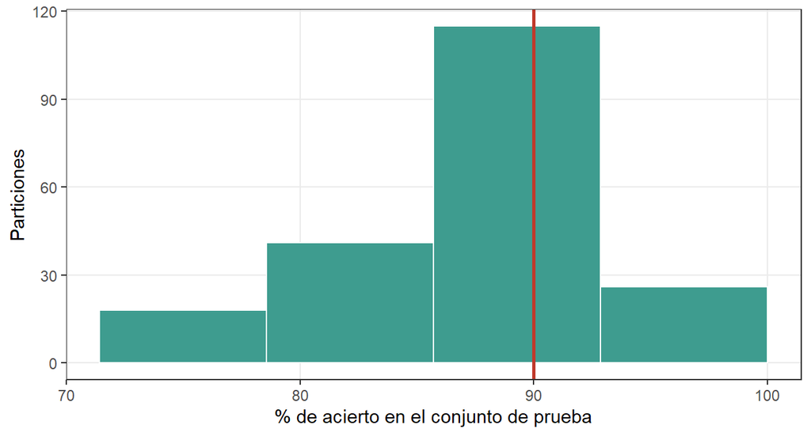

Figura 8: Porcentaje de acierto de la LDA en el conjunto de prueba para 200 particiones 80/20 distintas. Línea roja: acierto con validación cruzada dejando uno fuera (Taller 10).

```r
# Distribución del acierto según la partición
ggplot(tibble(Acierto = 100 * aciertos),
       aes(x = Acierto)) +
  geom_histogram(binwidth = 100 / 14,           # un pez de prueba = 7.1 %
                 boundary = 0,
                 fill = "#3E9C8F",
                 colour = "white") +
  geom_vline(xintercept = 100 * acc_cv,         # validación cruzada
             colour = "#C0392B",
             linewidth = 1) +
  labs(x = "% de acierto en el conjunto de prueba",
       y = "Particiones") +
  theme_bw() +
  theme(panel.grid.minor = element_blank())
```

El acierto va de 71.4 % a 100.0 % según la partición (el 90 % central entre 78.6 % y 100.0 %), con un promedio de 90.9 %, muy cerca del 90.0 % de la validación cruzada. Con 70 peces, una sola partición es una lotería; la validación cruzada dejando uno fuera usa todos los peces para probar y todos menos uno para entrenar, y no depende de una semilla.

**NotaCuándo sí separar un conjunto de prueba**

Con cientos o miles de observaciones (por ejemplo, fotografías de peces o registros acústicos), separar un conjunto de prueba es la práctica habitual y la que piden los revisores. Con pocas observaciones por grupo, se reporta la validación cruzada (dejando uno fuera o con k pliegues repetidos). Las LDA no necesitan estandarizar las medidas antes: sus asignaciones no cambian con la escala.

## 7. ANOSIM y MRPP

**Pregunta:** ¿Qué miden el ANOSIM y el MRPP que usaba el taller de 2024, y por qué el Taller 10 prefiere la PERMANOVA?

Las tres pruebas responden a la misma pregunta (¿difieren los grupos?) con estadísticos distintos sobre la misma matriz de distancias:

| Prueba | Estadístico | Qué compara |
| --- | --- | --- |
| ANOSIM (Clarke, 1993) | R = (r̄<sub>entre</sub> − r̄<sub>dentro</sub>) / (M/2) | Rangos de las distancias entre grupos y dentro de grupos |
| MRPP (Mielke et al., 1976) | δ y A = 1 − δ<sub>obs</sub> / δ<sub>esperado</sub> | Distancia promedio dentro de grupos frente a la esperada al azar |
| PERMANOVA (Anderson, 2001) | Pseudo-F y R² | Sumas de cuadrados de las distancias entre y dentro de grupos |

**Código**

```r
# ANOSIM, MRPP, PERMANOVA y betadisper sobre la misma distancia de los peces
set.seed(2026)
anos_p <- anosim(d_peces,
                 peces$Especie,
                 permutations = 999)
set.seed(2026)
mrpp_p <- mrpp(d_peces,
               peces$Especie,
               permutations = 999)
set.seed(2026)
perm_p <- adonis2(d_peces ~ Especie,
                  data = peces,
                  permutations = 999)
set.seed(2026)
pt_bd_p <- permutest(betadisper(d_peces, peces$Especie),
                     permutations = 999)

tibble(Prueba      = c("ANOSIM", "MRPP", "PERMANOVA", "betadisper"),
       Estadístico = c("R", "A", "R²", "F"),
       Valor       = c(anos_p$statistic, mrpp_p$A, perm_p$R2[1], F_bd(pt_bd_p)),
       p           = c(anos_p$signif, mrpp_p$Pvalue, p_de(perm_p), p_bd(pt_bd_p))) %>%
  tabla()
```

| Prueba | Estadístico | Valor | p |
| --- | --- | --- | --- |
| ANOSIM | R | 0.827 | 0.001 |
| MRPP | A | 0.434 | 0.001 |
| PERMANOVA | R² | 0.704 | 0.001 |
| betadisper | F | 3.281 | 0.021 |

**Código**

```r
# El R del ANOSIM a mano, con los rangos de las distancias
rangos   <- rank(d_peces)                                          # rango de cada distancia
mismo    <- as.dist(outer(peces$Especie, peces$Especie, "=="))     # 1 = misma especie
r_entre  <- mean(rangos[mismo == 0])
r_dentro <- mean(rangos[mismo == 1])
M <- length(rangos)                                                # número de pares

c(R_mano  = (r_entre - r_dentro) / (M / 2),
  R_vegan = unname(anos_p$statistic))
```

```
   R_mano   R_vegan
0.8266389 0.8266389
```

**Código**

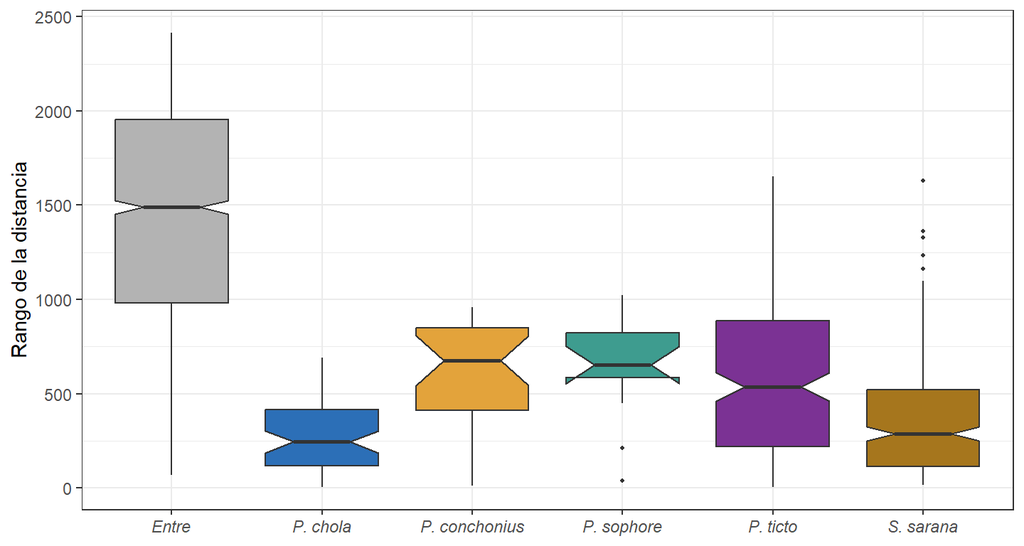

Figura 9: Rangos de las distancias entre peces de especies distintas (Entre) y dentro de cada especie. El R del ANOSIM compara el rango promedio entre grupos con el de dentro de grupos.

```r
# Rangos de distancia entre y dentro de especies
tibble(Rango = anos_p$dis.rank,
       Clase = anos_p$class.vec) %>%
  mutate(Clase = fct_relevel(Clase, "Between"),          # «Entre» primero
         Clase = fct_recode(Clase, Entre = "Between")) %>%
  ggplot(aes(x = Clase,
             y = Rango,
             fill = Clase)) +
  geom_boxplot(notch = TRUE,
               show.legend = FALSE,
               outlier.size = 0.8) +
  scale_fill_manual(values = c(Entre = "grey70", col_esp)) +
  labs(x = NULL,
       y = "Rango de la distancia") +
  theme_bw() +
  theme(axis.text.x = element_text(face = "italic"))
```

Las tres pruebas concluyen lo mismo (p = 0.001), pero sus estadísticos no son comparables entre sí: un R del ANOSIM de 0.83 no equivale a un R² de 0.70. El problema común del ANOSIM y del MRPP es la dispersión: los dos son **muy sensibles a diferencias de dispersión entre grupos**, y no tienen un modo de separar localización de dispersión ni de manejar diseños con más de un factor (Anderson y Walsh, 2013). En los peces, betadisper ya mostró dispersiones distintas (p = 0.021): el ANOSIM las mezcla con la diferencia de centroides.

**TipQué reportar**

Se usa la PERMANOVA con betadisper. Si una revista o un trabajo previo exige el ANOSIM, se reporta además de la PERMANOVA, con su R y su p, y se discute la dispersión. El MRPP casi no se usa hoy en ecología.

## 8. ANOVA univariadas después de la MANOVA

**Pregunta:** Si la MANOVA dice que las especies difieren, ¿en qué medidas difieren?

El taller de 2024 leía `summary.aov()` de la MANOVA: una ANOVA de una vía por cada medida. Es una forma legítima de explorar, siempre que se ajusten los p por las 10 pruebas y se recuerde que cada ANOVA tiene sus propios supuestos.

**Código**

```r
# MANOVA de las 10 medidas
manova_p <- manova(as.matrix(peces10) ~ Especie,
                   data = peces)

# Una ANOVA por medida, con el tamaño del efecto (eta²) y el p ajustado por Holm
uni <- summary.aov(manova_p) %>%                 # lista con una ANOVA por medida
  imap_dfr(function(a, nombre) {
    tibble(Medida = str_trim(sub("Response", "", nombre)),
           F      = a$`F value`[1],
           eta2   = a$`Sum Sq`[1] / sum(a$`Sum Sq`),   # fracción explicada por la especie
           p      = a$`Pr(>F)`[1])
  }) %>%
  mutate(p_Holm = p.adjust(p, method = "holm")) %>%
  arrange(desc(eta2))

uni %>%
  mutate(p      = format.pval(p, digits = 2),
         p_Holm = format.pval(p_Holm, digits = 2)) %>%
  tabla(col.names = c("Medida", "F (4 y 65 gl)", "η²", "p", "p ajustado (Holm)"))
```

| Medida | F (4 y 65 gl) | η² | p | p ajustado (Holm) |
| --- | --- | --- | --- | --- |
| M.1 | 127.357 | 0.887 | < 2e-16 | < 2e-16 |
| M.7 | 91.149 | 0.849 | < 2e-16 | < 2e-16 |
| M.13 | 36.139 | 0.690 | 7.0e-16 | 5.6e-15 |
| M.2 | 34.760 | 0.681 | 1.7e-15 | 1.2e-14 |
| M.18 | 27.014 | 0.624 | 3.2e-13 | 1.9e-12 |
| M.15 | 23.624 | 0.592 | 4.3e-12 | 2.2e-11 |
| M.4 | 20.709 | 0.560 | 4.8e-11 | 1.9e-10 |
| M.6 | 14.985 | 0.480 | 9.9e-09 | 3.0e-08 |
| M.5 | 10.492 | 0.392 | 1.3e-06 | 2.6e-06 |
| M.3 | 10.486 | 0.392 | 1.3e-06 | 2.6e-06 |

Las 10 medidas difieren entre especies después del ajuste de Holm. El **η²** (la fracción de la variación de cada medida que explica la especie) ordena su importancia: M.1 (0.89) y M.7 (0.85) encabezan la lista, las mismas medidas con mayor correlación con LD1. La MANOVA y la LDA miran **combinaciones** de medidas; las ANOVA miran cada una por separado. Una medida puede no diferir sola y aun así ser clave en una combinación.

### Los cuatro estadísticos de la MANOVA

El Taller 10 reporta Pillai y Wilks. `summary()` de la MANOVA ofrece cuatro estadísticos, que resumen de forma distinta los autovalores de la razón entre la variación entre especies y la de dentro de especies:

**Código**

```r
# Los cuatro estadísticos sobre la misma MANOVA
c("Pillai", "Wilks", "Hotelling-Lawley", "Roy") %>%
  map_dfr(function(prueba) {
    st <- summary(manova_p, test = prueba)$stats
    tibble(Estadistico = prueba,
           Valor  = st[1, 2],                     # la segunda columna lleva el nombre de la prueba
           F      = st[1, "approx F"],
           gl_num = st[1, "num Df"],
           gl_den = st[1, "den Df"],
           p      = format.pval(st[1, "Pr(>F)"], digits = 2))
  }) %>%
  tabla(digits = c(0, 3, 2, 0, 1, 0),
        col.names = c("Estadístico", "Valor", "F aprox.", "gl num.", "gl den.", "p"))
```

| Estadístico | Valor | F aprox. | gl num. | gl den. | p |
| --- | --- | --- | --- | --- | --- |
| Pillai | 2.513 | 9.97 | 40 | 236.0 | <2e-16 |
| Wilks | 0.003 | 19.67 | 40 | 214.2 | <2e-16 |
| Hotelling-Lawley | 29.052 | 39.58 | 40 | 218.0 | <2e-16 |
| Roy | 23.757 | 140.17 | 10 | 59.0 | <2e-16 |

| Estadístico | Qué resume | Cuándo preferirlo |
| --- | --- | --- |
| Pillai | Suma de la proporción explicada por cada función discriminante | El más robusto con grupos desiguales y supuestos a medias: el que se reporta |
| Wilks | Proporción **no** explicada (0 = separación total) | El más citado; equivalente a Pillai cuando los supuestos se cumplen |
| Hotelling-Lawley | Suma de los autovalores | Con dos grupos es la T² de Hotelling |
| Roy | Solo el mayor autovalor | Cuando la diferencia está en una sola dirección; su F es una cota superior, liberal |

Los cuatro coinciden en estos peces porque la diferencia entre especies es enorme. Ninguno prescinde de la normalidad multivariada ni de la homogeneidad de covarianzas; Pillai es solo el menos sensible a sus violaciones (Olson, 1976). La F de Roy (140.2) es mucho mayor que las otras porque se calcula como si toda la diferencia estuviera en LD1.

### Durbin-Watson con 200 órdenes de la misma base

El Taller 10 mostró que Durbin-Watson cambia con el orden de las filas. Repetido con 200 órdenes al azar de los mismos 70 peces:

**Código**

```r
# Suma de las 10 medidas (lo que prueba lm(M.1 + ... + M.18 ~ Especie))
peces_dw <- peces %>%
  mutate(Suma = rowSums(across(all_of(vars_p))))

# 200 órdenes al azar de las filas
set.seed(2026)
ordenes <- replicate(200,
                     sample(nrow(peces_dw)),
                     simplify = FALSE)

dw_200 <- map_dfr(ordenes, function(o) {
  set.seed(2026)                                   # misma semilla para el p por remuestreo
  r <- car::durbinWatsonTest(lm(Suma ~ Especie,
                                data = peces_dw[o, ]))
  tibble(DW = r$dw,
         p  = r$p)
})

c(DW_min     = min(dw_200$DW),
  DW_max     = max(dw_200$DW),
  pct_p_0.05 = 100 * mean(dw_200$p < 0.05))       # % de órdenes que «violan» la independencia
```

```
    DW_min     DW_max pct_p_0.05
  1.220298   2.464235   3.500000
```

Con los mismos peces y el mismo modelo, el estadístico va de 1.22 a 2.46 y el 3.5 % de los órdenes da p < 0.05, cerca del 5 % que se espera por azar. La prueba no mide nada del muestreo; mide el orden de digitación.

**AdvertenciaDiseño (RA1): cuándo sí sirve Durbin-Watson y qué usar en lugar de ella**

- **Sí sirve** cuando las filas tienen un orden real y se ordenan por él antes de probar: una serie de tiempo de capturas, estaciones a lo largo de un transecto, profundidades de un perfil. Con varias variables, el equivalente es la autocorrelación de los residuos (`acf()`) o un correlograma de Mantel de los residuos frente a la distancia (`vegan::mantel.correlogram()`).
- **No sirve** para individuos sin orden, como estos peces. Ahí la independencia se diagnostica con el diseño: la unidad de muestreo (lance, estación, visita), las filas repetidas (`duplicated()`) y si el factor se asignó a la unidad o varía dentro de ella.
- **Si hay seudorreplicación**, se corrige en el análisis: la unidad como bloque (`strata` o `blocks` en las permutaciones; la visita en la Parte 4 del Taller 10), permutando unidades completas (las estaciones del plancton en el estudio de caso), promediando por unidad, o con modelos mixtos.

## 9. El orden de los términos en la PERMANOVA

**Pregunta:** En el plancton del golfo de Urabá, ¿qué explica la composición: la salinidad o la zona?

`adonis2()` prueba los términos **en el orden de la fórmula** (`by = "terms"`, por defecto): cada término recibe la variación que no tomaron los anteriores. Si dos términos comparten información, el primero se queda con la parte común. En el estudio de caso del Taller 10, la salinidad y la zona aparecieron por separado; aquí se ponen juntas.

**Código**

```r
# Hoja «Riqueza» del plancton (como en el estudio de caso del Taller 10)
biol <- read_xlsx(ruta_datos("plancton.xlsx"),
                  sheet = "Riqueza") %>%
  mutate(Groups  = str_trim(Groups),
         Station = factor(Station),
         Size    = factor(Size),
         Layers  = recode_factor(Layers,
                                 Depth   = "Profunda",
                                 Surface = "Superficial"))
taxones <- unique(biol$Groups)

# Ambiente promedio por muestra
amb <- biol %>%
  group_by(Station, Size, Layers) %>%
  summarise(across(c(Temperature, Salinity, Density), mean),
            .groups = "drop")

# Abundancia por grupo, en formato ancho
tax <- biol %>%
  group_by(Station, Size, Layers, Groups) %>%
  summarise(Abundance = sum(Abundance),
            .groups = "drop") %>%
  pivot_wider(names_from = Groups,
              values_from = Abundance,
              values_fill = 0)

# Zona de cada estación
zonas <- tibble(Station = factor(c(2, 4, 7, 9, 13, 15)),
                Zona    = factor(rep(c("Fluvial", "Estuarina", "Marina"), each = 2),
                                 levels = c("Fluvial", "Estuarina", "Marina")))

pl_ancho <- amb %>%
  left_join(tax, by = c("Station", "Size", "Layers")) %>%
  left_join(zonas, by = "Station")

# Bray-Curtis del Taller 8 (raíz cuadrada y Wisconsin)
d_pl <- pl_ancho %>%
  select(all_of(taxones)) %>%
  sqrt() %>%
  wisconsin() %>%
  vegdist(method = "bray")
```

**Código**

```r
# Salinidad primero
set.seed(2026)
sal_zona <- adonis2(d_pl ~ Salinity + Zona,
                    data = pl_ancho,
                    by = "terms",                # en el orden de la fórmula
                    permutations = 999)

# Zona primero
set.seed(2026)
zona_sal <- adonis2(d_pl ~ Zona + Salinity,
                    data = pl_ancho,
                    by = "terms",
                    permutations = 999)

# Efectos marginales: cada término después del otro
set.seed(2026)
marg <- adonis2(d_pl ~ Salinity + Zona,
                data = pl_ancho,
                by = "margin",
                permutations = 999)

# ¿Cuánto de la salinidad explica la zona?
r2_sal_zona <- summary(lm(Salinity ~ Zona, data = pl_ancho))$r.squared

tibble(Análisis = c("Salinidad primero", "", "Zona primero", "", "Marginal", ""),
       Término  = c("Salinidad", "Zona", "Zona", "Salinidad", "Salinidad", "Zona"),
       R2       = c(sal_zona$R2[1:2], zona_sal$R2[1:2], marg$R2[1:2]),
       pseudo_F = c(sal_zona$F[1:2], zona_sal$F[1:2], marg$F[1:2]),
       p        = c(p_de(sal_zona, 1:2), p_de(zona_sal, 1:2), p_de(marg, 1:2))) %>%
  tabla(col.names = c("Análisis", "Término", "R²", "pseudo-F", "p"))
```

| Análisis | Término | R² | pseudo-F | p |
| --- | --- | --- | --- | --- |
| Salinidad primero | Salinidad | 0.196 | 5.536 | 0.001 |
|  | Zona | 0.095 | 1.333 | 0.225 |
| Zona primero | Zona | 0.267 | 3.760 | 0.001 |
|  | Salinidad | 0.024 | 0.683 | 0.661 |
| Marginal | Salinidad | 0.024 | 0.683 | 0.661 |
|  | Zona | 0.095 | 1.333 | 0.225 |

El término que entra primero se lleva casi todo: la salinidad sola explica el 19.6 % y la zona solo agrega 9.5 % (p = 0.225); al revés, la zona explica el 26.7 % y la salinidad agrega 2.4 %. Con efectos marginales (`by = "margin"`), cada término recibe solo lo que aporta después del otro, y ninguno se sostiene. No es una contradicción: la zona explica el 77.3 % de la variación de la salinidad, así que las dos cuentan casi la misma historia.

**ImportanteQué hacer con términos que se solapan**

- Decidir el orden **antes** de mirar los resultados, con un criterio del diseño: primero las covariables o los bloques que se quieren controlar, al final el factor de interés.
- Reportar el orden y el tipo de suma de cuadrados (`by = "terms"` o `by = "margin"`).
- Si los dos términos miden lo mismo (aquí, el gradiente salino), elegir el que responde la pregunta. La salinidad, además, se puede probar con las muestras como unidad; la zona solo con las estaciones (Taller 10, estudio de caso).
- Para repartir la variación sin elegir un orden, usar la partición de la varianza del material complementario del Taller 9.

## 10. betadisper con bloques

**Pregunta:** ¿Cómo se prueba la dispersión entre tributarios de las microalgas respetando que cada visita es un bloque?

En la Parte 4 del Taller 10, la PERMANOVA declaró la visita como bloque, pero betadisper se probó con permutación libre (p = 0.834). Una idea natural es pasarle a `permutest()` las mismas permutaciones restringidas:

**Código**

```r
# Microalgas: matrices F y Y
alg <- read_excel(ruta_datos("Microalgas.xlsx"),
                  sheet = "Microalgas") %>%
  rename(Fragilaria = Fragillaria,
         Nitzschia  = Nitzchia,
         Surirella  = Surilella,
         Gyrosigma  = Girosigma,
         Achnanthes = Achnantes) %>%
  mutate(Tributario = factor(Tributario),
         Visita     = factor(as.integer(sub(".*\\.", "", Cod))))   # T1.3 → 3

F_alg <- alg %>%
  select(Cod, Tributario, Visita)
Y_alg <- alg %>%
  select(Fragilaria:Pinnularia)

# Bray-Curtis del Taller 8
d_bray <- Y_alg %>%
  sqrt() %>%
  wisconsin() %>%
  vegdist(method = "bray")

# betadisper por tributario
bd_alg <- betadisper(d_bray,
                     F_alg$Tributario)

# Prueba con permutación libre y con bloques
set.seed(2026)
pt_libre <- permutest(bd_alg,
                      permutations = 999)
set.seed(2026)
pt_bloq  <- permutest(bd_alg,
                      permutations = how(nperm = 999,
                                         blocks = F_alg$Visita))   # solo dentro de cada visita

c(F         = F_bd(pt_libre),
  p_libre   = p_bd(pt_libre),
  p_bloques = p_bd(pt_bloq))
```

```
        F   p_libre p_bloques
0.1598243 0.8340000 0.2820000
```

El F es el mismo, pero el p pasa de 0.834 a 0.282. La razón está en el estadístico: `permutest()` calcula un F de una vía, **sin el bloque**, así que toda la variación entre visitas se queda en el residuo; al permutar solo dentro de cada visita, la distribución nula ya no corresponde a ese F. La solución es meter el bloque en el modelo de las distancias al centroide, igual que en la PERMANOVA:

**Código**

```r
# Distancia de cada muestra al centroide de su tributario
disp <- F_alg %>%
  mutate(Distancia = bd_alg$distances)

# ANOVA por permutación de las distancias, con la visita en el modelo y como bloque
set.seed(2026)
bd_bloque <- adonis2(disp["Distancia"] ~ Visita + Tributario,
                     data = disp,
                     method = "euclidean",                         # una sola variable: ANOVA
                     by = "terms",
                     permutations = how(nperm = 999,
                                        blocks = disp$Visita))
bd_bloque
```

```
Permutation test for adonis under reduced model
Terms added sequentially (first to last)
Blocks:  disp$Visita
Permutation: free
Number of permutations: 999

adonis2(formula = disp["Distancia"] ~ Visita + Tributario, data = disp, permutations = how(nperm = 999, blocks = disp$Visita), method = "euclidean", by = "terms")
           Df SumOfSqs      R2       F Pr(>F)
Visita      7 0.261067 0.89751 20.5155  0.358
Tributario  2 0.004361 0.01499  1.1995  0.358
Residual   14 0.025451 0.08750
Total      23 0.290879 1.00000
```

**Código**

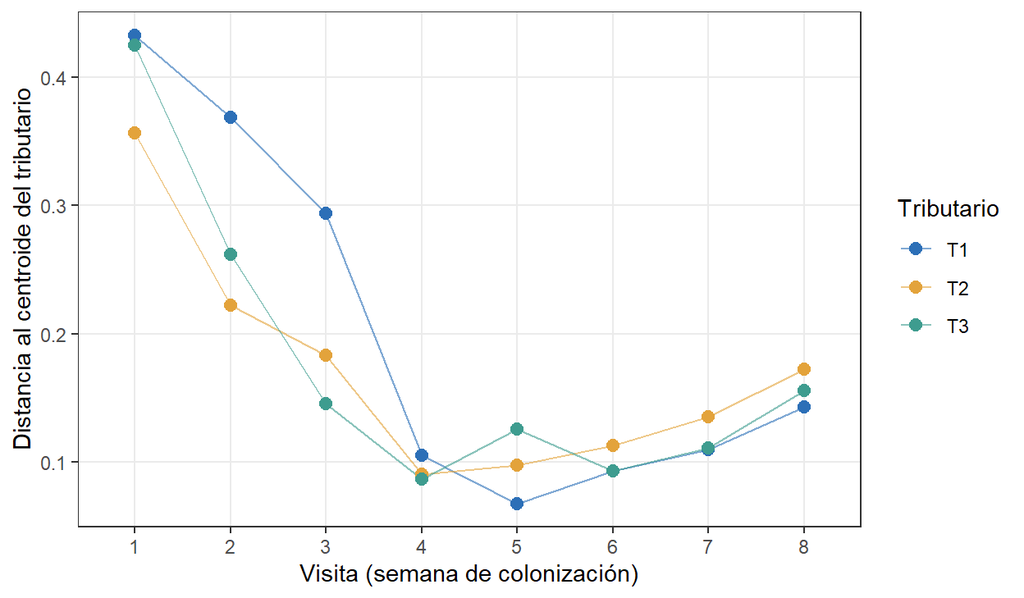

Figura 10: Distancia de cada muestra al centroide de su tributario (Bray-Curtis), por visita. Las primeras visitas están mucho más lejos de su centroide: la colonización empieza heterogénea y converge.

```r
# Distancia al centroide por visita y tributario
ggplot(disp,
       aes(x = Visita,
           y = Distancia,
           colour = Tributario,
           group = Tributario)) +
  geom_line(alpha = 0.6) +
  geom_point(size = 2.5) +
  scale_colour_manual(values = col_trib) +
  labs(x = "Visita (semana de colonización)",
       y = "Distancia al centroide del tributario") +
  theme_bw() +
  theme(panel.grid.minor = element_blank())
```

Con el bloque en el modelo, la dispersión entre tributarios sigue sin diferir (F = 1.20; p = 0.358), y la conclusión de localización del Taller 10 se mantiene. La Figura 10 muestra por qué el bloque importaba: la visita explica el 89.8 % de la variación de las distancias, porque en las primeras semanas cada sustrato tenía una comunidad distinta y con el tiempo convergieron, la misma convergencia que mostró el NMDS del Taller 8.

**NotaY en el plancton**

En el estudio de caso del Taller 10, la zona se asignó a la estación y hay solo dos estaciones por zona. La dispersión entre zonas no se puede probar bien con las muestras como unidad (sería pseudorreplicación) ni con las estaciones (dos por zona). Se describe con la figura y las distancias medias, sin un valor p.

## 11. manyglm en detalle: Wald, bloques, SIMPER y esfuerzo

**Pregunta:** ¿Qué decisiones de la Parte 5 del Taller 10 cambian la conclusión si se toman mal, y cómo se responde a un evaluador que las pregunta?

La Parte 5 dejó cuatro advertencias: reportar la razón de verosimilitud y no el Wald, poner la visita en el modelo y no en `block =`, preferir `p.uni = "adjusted"` al SIMPER para decir qué géneros cambian, y modelar conteos con el esfuerzo como `offset`. Esta sección muestra cada una con las microalgas de la sección 10 (`alg`, `F_alg`, `Y_alg`).

**Código**

```r
# GLM multivariado (Wang et al., 2012)
library(mvabund)

# Los dos modelos de la Parte 5 del Taller 10
Y_mv   <- mvabund(Y_alg)
m_pois <- manyglm(Y_mv ~ Visita + Tributario,
                  data = F_alg,
                  family = "poisson")
m_nb   <- manyglm(Y_mv ~ Visita + Tributario,
                  data = F_alg,
                  family = "negative.binomial")

# Prueba de la Parte 5: razón de verosimilitud, p por género ajustado
set.seed(2026)
an_nb <- anova(m_nb,
               nBoot = 999,
               p.uni = "adjusted",
               show.time = "none")
```

### 11.1 Género por género: θ, φ y AIC

En la Parte 5 las evidencias se resumieron para toda la comunidad. La tabla por género muestra que la binomial negativa no se elige «por mayoría»: donde hace falta mejora mucho el ajuste, y donde no hace falta su θ se dispara y vuelve a ser una Poisson.

**Código**

```r
# φ de Pearson de cada modelo
mu_p   <- fitted(m_pois)
mu_nb  <- fitted(m_nb)
var_nb <- mu_nb + sweep(mu_nb^2, 2, m_nb$theta, "/")     # Var = μ + μ²/θ

por_genero <- tibble(Genero      = colnames(Y_alg),
                     phi_Poisson = colSums((Y_alg - mu_p)^2 / mu_p) / m_pois$df.residual,
                     phi_BN      = colSums((Y_alg - mu_nb)^2 / var_nb) / m_nb$df.residual,
                     theta       = m_nb$theta,
                     dAIC        = AIC(m_pois) - AIC(m_nb)) %>%   # > 0: gana la binomial negativa
  arrange(desc(dAIC))

por_genero %>%
  mutate(theta = ifelse(theta > 100, "> 100", f1(theta))) %>%    # θ enorme = Poisson
  tabla(digits = 1,
        col.names = c("Género", "φ Poisson", "φ binomial negativa", "θ", "ΔAIC (Poisson − BN)"))
```

| Género | φ Poisson | φ binomial negativa | θ | ΔAIC (Poisson − BN) |
| --- | --- | --- | --- | --- |
| Melosira | 18.2 | 1.8 | 5.3 | 156.3 |
| Fragilaria | 13.0 | 1.5 | 4.3 | 115.6 |
| Eolimna | 10.4 | 1.3 | 5.6 | 94.5 |
| Planothidium | 11.3 | 1.5 | 13.5 | 93.4 |
| Lyngbya | 7.3 | 0.9 | 2.7 | 61.7 |
| Closterium | 4.1 | 0.7 | 1.1 | 24.2 |
| Cocconeis | 6.2 | 2.0 | 22.2 | 23.9 |
| Caloneis | 4.8 | 1.5 | 6.3 | 21.7 |
| Nitzschia | 4.8 | 1.7 | 15.9 | 16.3 |
| Achnanthes | 4.1 | 1.2 | 2.0 | 14.8 |
| Frustulia | 2.5 | 1.3 | 3.4 | 0.7 |
| Chamaepinnularia | 2.6 | 1.8 | 66.1 | -0.3 |
| Gomphonema | 4.5 | 2.8 | 10.7 | -0.3 |
| Surirella | 1.4 | 1.0 | 28.7 | -1.5 |
| Gyrosigma | 0.5 | 0.5 | > 100 | -2.0 |
| Eunotia | 0.9 | 0.9 | > 100 | -2.0 |
| Navicula | 2.6 | 2.3 | > 100 | -2.0 |
| Amphora | 2.0 | 1.9 | > 100 | -2.0 |
| Epithemia | 0.7 | 0.7 | > 100 | -2.0 |
| Pinnularia | 1.1 | 1.0 | > 100 | -2.0 |
| Cymbella | 0.0 | 0.0 | > 100 | -2.0 |

La binomial negativa mejora el AIC en 10 de los 21 géneros (ΔAIC > 2), con ganancias de hasta 156.3 unidades, justo en los géneros abundantes y agregados (*Melosira*, *Fragilaria*, *Planothidium*). En 7 géneros θ supera 100: la varianza extra (μ²/θ) es despreciable, el ajuste es el de la Poisson y el AIC solo paga el parámetro adicional (ΔAIC ≈ −2). Usar la binomial negativa para todos los géneros no tiene costo en la inferencia y evita elegir la familia especie por especie, que sería otra forma de buscar el p más pequeño.

**TipQué se reporta**

Una frase y, si se quiere, esta tabla en el material suplementario. Lo que **no** se reporta es una segunda tabla de resultados con el Poisson: si el diagnóstico dice que el Poisson está mal especificado, sus valores p son demasiado pequeños y no son «otro resultado».

### 11.2 Wald frente a razón de verosimilitud

`summary()` prueba cada coeficiente con el estadístico de **Wald** (estimado / error estándar). `anova()` prueba cada término comparando la verosimilitud del modelo con y sin él. Cuando un género falta en todas las muestras de un grupo, los dos dan respuestas opuestas:

**Código**

```r
# ¿En cuántos sustratos de cada tributario aparece Lyngbya?
table(Presente   = Y_alg$Lyngbya > 0,
      Tributario = F_alg$Tributario)
```

```
        Tributario
Presente T1 T2 T3
   FALSE  0  2  8
   TRUE   8  6  0
```

**Código**

```r
# Estimado y error estándar de Lyngbya para T3 (frente a T1)
c(estimado = coef(m_nb)["TributarioT3", "Lyngbya"],
  error_estandar = m_nb$stderr.coefficients["TributarioT3", "Lyngbya"])
```

```
      estimado error_estandar
     -17.77144      353.55347
```

*Lyngbya* no aparece en ningún sustrato de T3. El GLM intenta llevar su media en T3 a cero, lo que en escala log es −∞: el estimado se va a -17.8 y el error estándar a 353.6. El cociente queda casi en cero aunque la diferencia sea una de las más claras de toda la base (Hauck & Donner, 1977).

**Código**

```r
# Wald de summary() frente a razón de verosimilitud de anova()
set.seed(2026)
s_nb <- summary(m_nb,
                nBoot = 999,
                p.uni = "unadjusted",
                show.time = "none")
```

[output not shown]

**Código**

```r
# Géneros ausentes en un tributario y un género presente en los tres
gen_ej <- c("Lyngbya", "Surirella", "Eunotia", "Cymbella", "Melosira")

tibble(Genero    = gen_ej,
       Wald_T2   = s_nb$uni.test[gen_ej, "TributarioT2"],
       Wald_T3   = s_nb$uni.test[gen_ej, "TributarioT3"],
       LR        = an_nb$uni.test["Tributario", gen_ej],
       p_LR      = an_nb$uni.p["Tributario", gen_ej]) %>%
  tabla(col.names = c("Género", "Wald T2", "Wald T3", "LR (tributario)", "p ajustado (LR)"))
```

| Género | Wald T2 | Wald T3 | LR (tributario) | p ajustado (LR) |
| --- | --- | --- | --- | --- |
| Lyngbya | 2.664 | 0.050 | 37.902 | 0.001 |
| Surirella | 3.685 | 0.080 | 40.563 | 0.001 |
| Eunotia | 0.122 | 0.058 | 30.584 | 0.001 |
| Cymbella | 0.000 | 0.086 | 25.396 | 0.007 |
| Melosira | 1.786 | 0.217 | 4.062 | 0.604 |

Los cuatro primeros géneros faltan en al menos un tributario (*Cymbella* solo aparece en T3) y tienen p ajustados entre 0.001 y 0.007, pero su Wald en el contraste que involucra al tributario vacío no pasa de 0.09. *Melosira*, presente en los tres, tiene Wald y LR coherentes, ambos pequeños. Por eso la prueba que se reporta es `anova()`; `summary()` sirve para ver los coeficientes, no para decidir qué especies cambian.

**ImportanteCómo leer una tabla de Wald en un manuscrito**

Si un manuscrito presenta valores de Wald por especie, la pregunta del evaluador es directa: ¿qué pasa con las especies ausentes en un grupo? Esas son justo las que más cambian y las que el Wald declara «no significativas». Una tabla de Wald del Poisson al lado de una de la binomial negativa duplica el problema: el Poisson subestima el error estándar (sobredispersión) y el Wald falla con los ceros.

### 11.3 La visita: en el modelo o en `block =`

`anova.manyglm()` tiene un argumento `block` que remuestrea **bloques completos de filas** (aquí, las visitas con sus tres tributarios). Con ese remuestreo, el tributario de cada fila viaja con su visita y nunca se intercambia dentro de ella, que es justo el contraste que se quiere probar.

**Código**

```r
# Dev y p del tributario de una prueba anova()
fila_trib <- function(a, modelo, remuestreo) {
  tibble(Modelo     = modelo,
         Remuestreo = remuestreo,
         Dev        = a$table["Tributario", "Dev"],
         p          = a$table["Tributario", "Pr(>Dev)"])
}

# Modelo sin la visita, para ver el papel de block = por separado
m_nb_t <- manyglm(Y_mv ~ Tributario,
                  data = F_alg,
                  family = "negative.binomial")

# Visita en el modelo, remuestreo de visitas completas
set.seed(2026)
a_mod_bloq <- anova(m_nb,
                    nBoot = 999,
                    block = F_alg$Visita,              # remuestrea visitas completas
                    show.time = "none")

# Sin la visita en el modelo, libre y con bloques
set.seed(2026)
a_sin_libre <- anova(m_nb_t,
                     nBoot = 999,
                     show.time = "none")
set.seed(2026)
a_sin_bloq  <- anova(m_nb_t,
                     nBoot = 999,
                     block = F_alg$Visita,
                     show.time = "none")

# Las cuatro combinaciones (an_nb es la prueba de la Parte 5)
bind_rows(fila_trib(an_nb,       "Y ~ Visita + Tributario", "Filas (libre)"),
          fila_trib(a_mod_bloq,  "Y ~ Visita + Tributario", "block = Visita"),
          fila_trib(a_sin_libre, "Y ~ Tributario",          "Filas (libre)"),
          fila_trib(a_sin_bloq,  "Y ~ Tributario",          "block = Visita")) %>%
  tabla(col.names = c("Modelo", "Remuestreo", "Dev (tributario)", "p"))
```

| Modelo | Remuestreo | Dev (tributario) | p |
| --- | --- | --- | --- |
| Y ~ Visita + Tributario | Filas (libre) | 322.124 | 0.001 |
| Y ~ Visita + Tributario | block = Visita | 322.124 | 0.201 |
| Y ~ Tributario | Filas (libre) | 140.099 | 0.004 |
| Y ~ Tributario | block = Visita | 140.099 | 0.757 |

El estadístico del tributario es el mismo con y sin `block =`; lo que cambia es la distribución nula. Con la visita en el modelo y remuestreo de filas, p = 0.001; con `block = Visita`, p = 0.201. Sin la visita en el modelo, el Dev baja a 140.1 (sin la visita, cada θ absorbe la variación entre semanas y el tributario se mide con más ruido) y el p con bloques llega a 0.757.

**AdvertenciaRegla de diseño (RA1)**

- **Factor que varía dentro del bloque** (tributario dentro de visita; tratamiento dentro de parcela): el bloque va **en el modelo**, como en la PERMANOVA (`Visita + Tributario`).
- **Factor asignado al bloque completo** (zona asignada a la estación en el plancton; época si cada estación se muestrea una sola vez): `block =` con la unidad de asignación, para no tratar las muestras de una misma estación como réplicas independientes.

Es la misma distinción entre `strata`/`blocks` de la PERMANOVA y la pseudorreplicación de la Semana 1.

### 11.4 SIMPER frente a `p.uni = "adjusted"`

SIMPER (Clarke, 1993) descompone la disimilitud de Bray-Curtis promedio entre dos grupos en el aporte de cada especie. Se usa a menudo para decir «qué especies separan los grupos», pero mide otra cosa: las especies abundantes y variables aportan mucho a la disimilitud **dentro y entre** grupos, cambien o no de media (Warton et al., 2012).

**Código**

```r
# SIMPER de T1 frente a T3 con los conteos
set.seed(2026)
sp_alg <- simper(Y_alg,
                 F_alg$Tributario,
                 permutations = 999)

# Las ocho especies que más aportan y su p ajustado del manyglm
summary(sp_alg)$T1_T3 %>%
  as_tibble(rownames = "Genero") %>%
  slice_head(n = 8) %>%
  select(Genero, average, cumsum, p) %>%
  left_join(tibble(Genero = colnames(Y_alg),
                   p_manyglm = an_nb$uni.p["Tributario", ]),
            by = "Genero") %>%
  tabla(col.names = c("Género", "Aporte medio", "Aporte acumulado", "p SIMPER", "p ajustado manyglm"))
```

| Género | Aporte medio | Aporte acumulado | p SIMPER | p ajustado manyglm |
| --- | --- | --- | --- | --- |
| Melosira | 0.079 | 0.166 | 0.628 | 0.604 |
| Cocconeis | 0.077 | 0.327 | 0.237 | 0.294 |
| Planothidium | 0.062 | 0.456 | 0.899 | 0.515 |
| Fragilaria | 0.038 | 0.536 | 0.309 | 0.427 |
| Lyngbya | 0.031 | 0.601 | 0.072 | 0.001 |
| Eolimna | 0.031 | 0.666 | 0.979 | 0.806 |
| Navicula | 0.024 | 0.717 | 0.319 | 0.035 |
| Nitzschia | 0.023 | 0.765 | 0.452 | 0.418 |

Los tres primeros géneros del SIMPER (*Melosira*, *Cocconeis* y *Planothidium*) acumulan cerca de la mitad de la disimilitud entre T1 y T3, y ninguno cambia según el manyglm ni según la propia permutación del SIMPER. Son los más abundantes y variables. *Lyngbya*, ausente en T3, aparece más abajo en el SIMPER, pero es uno de los cambios más claros en el manyglm.

**TipQué decir al evaluador**

«Para identificar los taxones que difieren entre grupos se usaron las pruebas univariadas del GLM multivariado con ajuste por multiplicidad (`p.uni = "adjusted"`), en lugar de SIMPER, que confunde el efecto de la media con la variabilidad de las especies abundantes (Warton et al., 2012).» Si se quiere conservar el SIMPER, se presenta como descripción de la disimilitud, no como prueba de qué especies cambian.

### 11.5 Conteos, densidades y esfuerzo de muestreo

Las familias Poisson y binomial negativa suponen **conteos**: números enteros cuya varianza depende de la media. Una densidad (células/mL, individuos/m²) pierde esa relación, porque el mismo valor puede venir de 2 células en 1 mL o de 200 en 100 mL. Si el esfuerzo (volumen filtrado, área raspada, tiempo de arrastre) varió entre muestras, se modela el conteo y el esfuerzo entra como `offset`:

**Código**

```r
# Ejemplo con una columna de esfuerzo (no existe en la base de microalgas)
F_alg <- F_alg %>%
  mutate(Area_cm2 = c(...))                                      # área raspada en cada sustrato

m_nb_off <- manyglm(Y_mv ~ Visita + Tributario + offset(log(Area_cm2)),
                    data = F_alg,
                    family = "negative.binomial")                # modela conteo / área

set.seed(2026)
anova(m_nb_off,
      nBoot = 999,
      p.uni = "adjusted")
```

Con `offset(log(esfuerzo))`, el modelo estima la tasa (conteo por unidad de esfuerzo) sin perder la distribución de conteos, y los coeficientes se leen como cambios en la densidad. En las microalgas del Taller 10 todos los sustratos se trataron como unidades de igual esfuerzo; si el área raspada o el volumen revisado hubiera variado, el offset sería obligatorio. Si una base solo trae densidades, se recuperan los conteos multiplicando por el volumen o el área de cada muestra; si eso no es posible, la PERMANOVA sobre Bray-Curtis sigue siendo válida, pero un GLM de conteos no lo es.

### 11.6 Las preguntas del evaluador, en una tabla

| Pregunta del evaluador | Respuesta | Dónde |
| --- | --- | --- |
| ¿Qué variable responde cada modelo? | Conteos por especie y muestra; `offset(log(esfuerzo))` si el esfuerzo varió | 11.5 |
| ¿Cómo se detectó la sobredispersión? | Media–varianza, φ, residuos de Dunn-Smyth y AIC, por género | Taller 10, Parte 5; 11.1 |
| ¿Por qué hay dos modelos en la tabla? | Se reporta solo la binomial negativa, con razón de verosimilitud (`anova()`) | 11.1; 11.2 |
| ¿Centroide o dispersión? ¿Y el SIMPER? | PERMANOVA + betadisper con el bloque en el modelo; especies con `p.uni = "adjusted"` | 10; 11.4 |
| (Diseño) ¿La estación es réplica? | El bloque en el modelo para factores dentro del bloque; `block =` para factores asignados al bloque | 11.3 |

## 12. Ejercicios de práctica (sin nota)

Para practicar antes del estudio de caso:

1. Repita la tabla de la sección 1 con la distancia de Manhattan (`dist(scale(fq), method = "manhattan")`). ¿Cambian los grupos con k = 2?
2. Haga el k-means de los peces con las medidas estandarizadas (`scale(peces10)`). ¿Sube o baja el índice de Rand ajustado frente a las especies?
3. Rehaga el biplot de la sección 5 con LD1 y LD3. ¿Qué especies separa la tercera función?
4. Corra la LDA solo con las cuatro *Puntius* (sin *S. sarana*) y compare su acierto con validación cruzada con el de las cinco especies.
5. Corra el ANOSIM de las microalgas por tributario con la visita como bloque (`permutations = how(nperm = 999, blocks = F_alg$Visita)`) y compare su R con el R² de la PERMANOVA del Taller 10.
6. En la sección 9, agregue la malla y la capa al modelo después de la salinidad. ¿Cambia el aporte de la zona?
7. En la sección 11.4, repita el SIMPER entre T1 y T2. ¿Los géneros que más aportan coinciden con los que el `manyglm` declara con p ajustado < 0.05?
8. Ajuste el `manyglm` de la Parte 5 con la visita como variable numérica (`as.numeric(Visita)`) en lugar de factor. ¿Cambia la conclusión del tributario? ¿Qué supone sobre la colonización?

## Referencias

- Anderson, M. J. (2001). A new method for non-parametric multivariate analysis of variance. *Austral Ecology*, 26(1), 32–46. https://doi.org/10.1111/j.1442-9993.2001.01070.pp.x
- Anderson, M. J. (2006). Distance-based tests for homogeneity of multivariate dispersions. *Biometrics*, 62(1), 245–253. https://doi.org/10.1111/j.1541-0420.2005.00440.x
- Anderson, M. J., & Walsh, D. C. I. (2013). PERMANOVA, ANOSIM, and the Mantel test in the face of heterogeneous dispersions: What null hypothesis are you testing? *Ecological Monographs*, 83(4), 557–574. https://doi.org/10.1890/12-2010.1
- Borcard, D., Gillet, F., & Legendre, P. (2018). *Numerical Ecology with R* (2nd ed.). Springer. https://doi.org/10.1007/978-3-319-71404-2
- Clarke, K. R. (1993). Non-parametric multivariate analyses of changes in community structure. *Australian Journal of Ecology*, 18(1), 117–143. https://doi.org/10.1111/j.1442-9993.1993.tb00438.x
- Dunn, P. K., & Smyth, G. K. (1996). Randomized quantile residuals. *Journal of Computational and Graphical Statistics*, 5(3), 236–244. https://doi.org/10.1080/10618600.1996.10474708
- Durbin, J., & Watson, G. S. (1950). Testing for serial correlation in least squares regression: I. *Biometrika*, 37(3/4), 409–428. https://doi.org/10.2307/2332391
- Gupta, D., Dwivedi, A. K., & Tripathi, M. (2018). Taxonomic validation of five fish species of subfamily Barbinae from the Ganga river system of northern India using traditional and truss analyses. *PLoS ONE*, 13(10), e0206031. https://doi.org/10.1371/journal.pone.0206031 — Base de datos `datos.xlsx`.
- Hartigan, J. A., & Wong, M. A. (1979). Algorithm AS 136: A K-means clustering algorithm. *Journal of the Royal Statistical Society. Series C (Applied Statistics)*, 28(1), 100–108. https://doi.org/10.2307/2346830
- Hauck, W. W., & Donner, A. (1977). Wald’s test as applied to hypotheses in logit analysis. *Journal of the American Statistical Association*, 72(360), 851–853. https://doi.org/10.1080/01621459.1977.10479969
- Hubert, L., & Arabie, P. (1985). Comparing partitions. *Journal of Classification*, 2, 193–218. https://doi.org/10.1007/BF01908075
- Hurlbert, S. H. (1984). Pseudoreplication and the design of ecological field experiments. *Ecological Monographs*, 54(2), 187–211. https://doi.org/10.2307/1942661
- Kaufman, L., & Rousseeuw, P. J. (1990). *Finding Groups in Data: An Introduction to Cluster Analysis*. Wiley.
- Legendre, P., & Legendre, L. (2012). *Numerical Ecology* (3rd ed.). Elsevier.
- Mielke, P. W., Berry, K. J., & Johnson, E. S. (1976). Multi-response permutation procedures for a priori classifications. *Communications in Statistics – Theory and Methods*, 5(14), 1409–1424. https://doi.org/10.1080/03610927608827451
- Oksanen, J., Simpson, G. L., Blanchet, F. G., Kindt, R., Legendre, P., Minchin, P. R., et al. (2025). *vegan: Community Ecology Package*. https://CRAN.R-project.org/package=vegan
- Olson, C. L. (1976). On choosing a test statistic in multivariate analysis of variance. *Psychological Bulletin*, 83(4), 579–586. https://doi.org/10.1037/0033-2909.83.4.579
- Osorio Ávila, F. J., Rodríguez Barrios, J., & Montoya Moreno, Y. (2015). Sucesión de microalgas perifíticas en tributarios del río Gaira, Sierra Nevada de Santa Marta-Colombia. *Acta Biológica Colombiana*, 20(2), 119–131. https://doi.org/10.15446/abc.v20n2.41932 — Base de datos `Microalgas`.
- Rodríguez-Barrios, J. (2023). *Análisis de datos ecológicos y ambientales: aplicaciones con el programa R*. Díaz de Santos. — Base de datos `FQmarino.csv`.
- Vargas-Ospina, B., Córdoba-Bejarano, J. A., Riquelme-Bugueño, R., Flórez-Leiva, L., & Rodríguez-Barrios, J. (2025). Short-term variations of mesozooplankton in a tropical estuary, Caribbean Colombia. *Wetlands*, 45, 83. https://doi.org/10.1007/s13157-025-01951-7 — Base de datos `plancton.xlsx`.
- Venables, W. N., & Ripley, B. D. (2002). *Modern Applied Statistics with S* (4th ed.). Springer. — Paquete `MASS`.
- Wang, Y., Naumann, U., Wright, S. T., & Warton, D. I. (2012). mvabund – an R package for model-based analysis of multivariate abundance data. *Methods in Ecology and Evolution*, 3(3), 471–474. https://doi.org/10.1111/j.2041-210X.2012.00190.x
- Warton, D. I., Wright, S. T., & Wang, Y. (2012). Distance-based multivariate analyses confound location and dispersion effects. *Methods in Ecology and Evolution*, 3(1), 89–101. https://doi.org/10.1111/j.2041-210X.2011.00127.x

**Nota**

Las figuras y el código de este material son de elaboración propia a partir de las bases citadas. La función `rand_aj()` se escribió siguiendo la definición de Hubert y Arabie (1985). No reproducen ejercicios ni código de las fuentes bibliográficas.